# Olink analysis eliteATHENA and 2000HIV

Albert Groenendijk & Nadira Vadaq

2022-11-22

Updated July and December 2023 and January 2024 by Nadira. Major revisions, refactor and expansions by Albert, starting 9 February 2024, further additions October and December 2024.

```r
working_dir <- c("C:/Users/accou/Documents/PHD_2_projects/7_Code_for_github/AthenaOlink_Cleaning/")

library(FactoMineR)
library(dplyr)
library(magrittr)
library(lubridate)
library(table1)
library(ggbiplot)
library(ggplot2)
library(openxlsx)
library(limma)
library(tidyverse)
library(ggrepel)
```

## 0.1 Read data elite ATHENA comparison 1

```r
##### Read Olink comparison 1 file #####
# Check missingness of clinical information:
master_df <-  openxlsx::read.xlsx(paste0(working_dir, "Inputs/Olink_SHM_EC_vs_VC_183samp_2420Prots_masterdata.xlsx"))
colSums(is.na(master_df[,c(1:21)]))
```

```
##        COMP_1_2_ID             CENTER            T1_DATE Days_since_Jan2001
##                  0                  0                  0                  0
##       Storage_time         SEASON_SIN         SEASON_COS                 ID
##                  0                  0                  0                  0
##         ID_2000HIV         NONVIREMIC              GROUP            HIV_DUR
##                157                  0                  0                  0
##                AGE                SEX             T1_BMI       SMOKING_EVER
##                  0                  0                 31                 17
##    SMOKING_CURRENT                 VL                CD4           CD4NADIR
##                 14                  0                  2                  0
##          ETHNICITY
##                 23
```

```r
# In summary, no. of missing in the following columns: 31 BMI, 23 ETHNICITY, 14 SMOKING_CURRENT and 2 CD4

# Read and clean the file
master_df <-  master_df %>%
  mutate_at(c(2,10,11,14,16,17,21), as.factor)%>%
  mutate(NONVIREMIC =  factor(NONVIREMIC, levels = c(1,0),labels = c("EC","VC")))

summary(master_df$NONVIREMIC)
```

```
##  EC  VC
##  36 147
```

```r
# ART-naïve VC           EC
#          147           36

##### Summary statistics comparison 1 file #####
# from library table1
df_m <- master_df #%>%

# run table1 function for summary statistics of overall cohort
  table1(~ AGE +
           SEX +
           T1_BMI +
           CENTER +
           SMOKING_CURRENT +
           ETHNICITY +
           CD4 +
           CD4NADIR +
           VL +
           HIV_DUR +
           Storage_time| NONVIREMIC, data=df_m)
```

|  | EC (N=36) | VC (N=147) | Overall (N=183) |
| --- | --- | --- | --- |
| AGE |  |  |  |
| Mean (SD) | 47.6 (13.1) | 40.1 (10.1) | 41.6 (11.1) |
| Median [Min, Max] | 49.2 [21.8, 68.4] | 40.3 [19.7, 68.9] | 41.3 [19.7, 68.9] |
| SEX |  |  |  |
| FEMALE | 15 (41.7%) | 40 (27.2%) | 55 (30.1%) |
| MALE | 21 (58.3%) | 107 (72.8%) | 128 (69.9%) |
| T1_BMI |  |  |  |
| Mean (SD) | 27.6 (5.06) | 24.9 (3.73) | 25.4 (4.12) |
| Median [Min, Max] | 27.7 [18.1, 40.0] | 24.5 [16.2, 37.6] | 24.9 [16.2, 40.0] |
| Missing | 8 (22.2%) | 23 (15.6%) | 31 (16.9%) |
| CENTER |  |  |  |
| EMC | 7 (19.4%) | 45 (30.6%) | 52 (28.4%) |
| LUMC | 0 (0%) | 5 (3.4%) | 5 (2.7%) |
| MSZ | 8 (22.2%) | 8 (5.4%) | 16 (8.7%) |
| OLVG | 15 (41.7%) | 68 (46.3%) | 83 (45.4%) |
| RAD | 4 (11.1%) | 6 (4.1%) | 10 (5.5%) |
| UMCU | 2 (5.6%) | 15 (10.2%) | 17 (9.3%) |
| SMOKING_CURRENT |  |  |  |
| 0 | 16 (44.4%) | 69 (46.9%) | 85 (46.4%) |
| 1 | 17 (47.2%) | 67 (45.6%) | 84 (45.9%) |
| Missing | 3 (8.3%) | 11 (7.5%) | 14 (7.7%) |
| ETHNICITY |  |  |  |
| Asian | 2 (5.6%) | 1 (0.7%) | 3 (1.6%) |
| Black | 7 (19.4%) | 46 (31.3%) | 53 (29.0%) |
| Hispanic | 1 (2.8%) | 3 (2.0%) | 4 (2.2%) |
| Mixed | 2 (5.6%) | 5 (3.4%) | 7 (3.8%) |
| White | 16 (44.4%) | 77 (52.4%) | 93 (50.8%) |
| Missing | 8 (22.2%) | 15 (10.2%) | 23 (12.6%) |
| CD4 |  |  |  |
| Mean (SD) | 1040 (452) | 671 (269) | 741 (342) |
| Median [Min, Max] | 1010 [160, 2280] | 610 [143, 2040] | 670 [143, 2280] |
| Missing | 2 (5.6%) | 0 (0%) | 2 (1.1%) |
| CD4NADIR |  |  |  |
| Mean (SD) | 834 (447) | 561 (200) | 615 (287) |
| Median [Min, Max] | 790 [120, 2510] | 530 [143, 1170] | 559 [120, 2510] |
| VL |  |  |  |
| Mean (SD) | 45.4 (157) | 2520 (2870) | 2040 (2760) |
| Median [Min, Max] | 0 [0, 857] | 1450 [0, 9880] | 712 [0, 9880] |
| HIV_DUR |  |  |  |
| Mean (SD) | 6.77 (7.44) | 6.78 (6.37) | 6.78 (6.57) |
| Median [Min, Max] | 5.19 [0.0300, 34.5] | 5.39 [0, 31.2] | 5.39 [0, 34.5] |
| Storage_time |  |  |  |
| Mean (SD) | 2980 (1310) | 4500 (1470) | 4200 (1560) |
| Median [Min, Max] | 2880 [439, 6400] | 4570 [836, 7350] | 4080 [439, 7350] |

```r
#Statistics
df_lib <- df_m
names(df_lib)[1:30]
```

```
##  [1] "COMP_1_2_ID"              "CENTER"
##  [3] "T1_DATE"                  "Days_since_Jan2001"
##  [5] "Storage_time"             "SEASON_SIN"
##  [7] "SEASON_COS"               "ID"
##  [9] "ID_2000HIV"               "NONVIREMIC"
## [11] "GROUP"                    "HIV_DUR"
## [13] "AGE"                      "SEX"
## [15] "T1_BMI"                   "SMOKING_EVER"
## [17] "SMOKING_CURRENT"          "VL"
## [19] "CD4"                      "CD4NADIR"
## [21] "ETHNICITY"                "GP2_Cardiometabolic"
## [23] "WASF1_Cardiometabolic"    "HK2_Cardiometabolic"
## [25] "VSTM2L_Cardiometabolic"   "TIA1_Cardiometabolic"
## [27] "MPHOSPH8_Cardiometabolic" "HNRNPK_Cardiometabolic"
## [29] "CEBPB_Cardiometabolic"    "VIM_Cardiometabolic"
```

```r
#wilcoxon/ttest
modelList<-list()
for(i in c(12,13,15,5,18:20)){
  fmla <- formula(paste(names(df_lib)[i], " ~ NONVIREMIC"))
  modelList[[i]]<-wilcox.test(fmla, data = df_lib, paired = FALSE)
}
modelList
```

```
## [[1]]
## NULL
##
## [[2]]
## NULL
##
## [[3]]
## NULL
##
## [[4]]
## NULL
##
## [[5]]
##
##  Wilcoxon rank sum test with continuity correction
##
## data:  Storage_time by NONVIREMIC
## W = 1161, p-value = 1.874e-07
## alternative hypothesis: true location shift is not equal to 0
##
##
## [[6]]
## NULL
##
## [[7]]
## NULL
##
## [[8]]
## NULL
##
## [[9]]
## NULL
##
## [[10]]
## NULL
##
## [[11]]
## NULL
##
## [[12]]
```

[output cut: 45 more lines]

```
##
##  Wilcoxon rank sum test with continuity correction
##
## data:  CD4 by NONVIREMIC
## W = 3848.5, p-value = 9.576e-07
## alternative hypothesis: true location shift is not equal to 0
##
##
## [[20]]
##
##  Wilcoxon rank sum test with continuity correction
##
## data:  CD4NADIR by NONVIREMIC
## W = 3841.5, p-value = 2.72e-05
## alternative hypothesis: true location shift is not equal to 0
```

```r
rm(modelList)

#chisquare
df_lib[,c(2,14,17,21,10)] %>%
  dplyr::summarise_each(funs(chisq.test(.,
                                 df_lib$NONVIREMIC)$p.value), -one_of("NONVIREMIC"))
```

```
##        CENTER       SEX SMOKING_CURRENT ETHNICITY
## 1 0.009428364 0.1355208       0.9697735 0.1676312
```

```r
rm(df_m, df_lib)
```

### 0.1.1 ADDENDUM 2/12/2024 UPDATE TABLE 1

```r
# Custom rendering function
rndr <- function(x, name, ...) {
  if (is.numeric(x)) {
    med_iqr <- function(x) {
      iqr <- quantile(x, c(0.25, 0.75), na.rm = TRUE)
      sprintf("%.1f [%.1f, %.1f]", median(x, na.rm = TRUE), iqr[1], iqr[2])
    }
    return(med_iqr(x))
  } else {
    return(render.categorical.default(x))
  }
}

# Use the custom rendering function in table1()
df_m <- master_df #%>%

# run table1 function for summary statistics of overall cohort
  table1(~ AGE +
           SEX +
           T1_BMI +
           CENTER +
           SMOKING_CURRENT +
           ETHNICITY +
           CD4 +
           CD4NADIR +
           VL +
           HIV_DUR +
           Storage_time| NONVIREMIC, data=df_m, render = rndr)
```

|  | EC (N=36) | VC (N=147) | Overall (N=183) |
| --- | --- | --- | --- |
| AGE | 49.2 [38.1, 58.1] | 40.3 [32.8, 47.3] | 41.3 [33.2, 48.6] |
| SEX |  |  |  |
| FEMALE | 15 (41.7%) | 40 (27.2%) | 55 (30.1%) |
| MALE | 21 (58.3%) | 107 (72.8%) | 128 (69.9%) |
| T1_BMI | 27.7 [24.3, 30.0] | 24.5 [22.7, 26.4] | 24.9 [22.8, 27.4] |
| CENTER |  |  |  |
| EMC | 7 (19.4%) | 45 (30.6%) | 52 (28.4%) |
| LUMC | 0 (0%) | 5 (3.4%) | 5 (2.7%) |
| MSZ | 8 (22.2%) | 8 (5.4%) | 16 (8.7%) |
| OLVG | 15 (41.7%) | 68 (46.3%) | 83 (45.4%) |
| RAD | 4 (11.1%) | 6 (4.1%) | 10 (5.5%) |
| UMCU | 2 (5.6%) | 15 (10.2%) | 17 (9.3%) |
| SMOKING_CURRENT |  |  |  |
| 0 | 16 (44.4%) | 69 (46.9%) | 85 (46.4%) |
| 1 | 17 (47.2%) | 67 (45.6%) | 84 (45.9%) |
| ETHNICITY |  |  |  |
| Asian | 2 (5.6%) | 1 (0.7%) | 3 (1.6%) |
| Black | 7 (19.4%) | 46 (31.3%) | 53 (29.0%) |
| Hispanic | 1 (2.8%) | 3 (2.0%) | 4 (2.2%) |
| Mixed | 2 (5.6%) | 5 (3.4%) | 7 (3.8%) |
| White | 16 (44.4%) | 77 (52.4%) | 93 (50.8%) |
| CD4 | 1013.1 [700.0, 1325.0] | 610.0 [489.5, 840.0] | 670.0 [495.0, 920.0] |
| CD4NADIR | 790.0 [585.0, 1017.5] | 530.0 [411.0, 695.0] | 559.0 [422.0, 770.0] |
| VL | 0.0 [0.0, 0.0] | 1450.0 [195.0, 3945.0] | 712.0 [0.0, 2870.0] |
| HIV_DUR | 5.2 [1.4, 8.6] | 5.4 [2.0, 9.9] | 5.4 [1.6, 9.9] |
| Storage_time | 2878.0 [2187.5, 3813.8] | 4567.0 [3436.5, 5578.5] | 4078.0 [3000.0, 5439.0] |

### 0.1.2 Transform T1_DATE and verify seasonality and storagetime

```r
# transform date
master_df$T1_DATE <- as.Date(master_df$T1_DATE, origin = "1899-12-30")


str(master_df[,c("CENTER","T1_DATE","Days_since_Jan2001","Storage_time","SEASON_SIN","SEASON_COS",
             "NONVIREMIC","GROUP","HIV_DUR","AGE","SEX",
             "T1_BMI","SMOKING_EVER","SMOKING_CURRENT","VL","CD4","CD4NADIR","ETHNICITY")])
```

```
## 'data.frame':    183 obs. of  18 variables:
##  $ CENTER            : Factor w/ 6 levels "EMC","LUMC","MSZ",..: 5 4 3 4 4 6 3 1 1 1 ...
##  $ T1_DATE           : Date, format: "2015-01-12" "2013-09-18" ...
##  $ Days_since_Jan2001: num  5124 4643 2067 3767 5139 ...
##  $ Storage_time      : num  2546 3027 5603 3903 2531 ...
##  $ SEASON_SIN        : num  0.181 -0.972 -0.842 0.921 0.426 ...
##  $ SEASON_COS        : num  0.983 -0.236 -0.54 -0.39 0.905 ...
##  $ NONVIREMIC        : Factor w/ 2 levels "EC","VC": 2 1 2 2 2 2 1 2 2 2 ...
##  $ GROUP             : Factor w/ 1 level "EC": 1 1 1 1 1 1 1 1 1 1 ...
##  $ HIV_DUR           : num  7.31 7.1 0.04 17.83 5.29 ...
##  $ AGE               : num  42.9 64.1 33.8 48.8 45.1 ...
##  $ SEX               : Factor w/ 2 levels "FEMALE","MALE": 2 1 2 2 2 2 2 1 1 2 ...
##  $ T1_BMI            : num  22.8 24.2 26.2 NA 22.5 ...
##  $ SMOKING_EVER      : Factor w/ 2 levels "0","1": 2 2 2 1 2 NA 2 2 NA 2 ...
##  $ SMOKING_CURRENT   : Factor w/ 2 levels "0","1": 2 1 2 1 2 NA 2 1 NA 2 ...
##  $ VL                : num  3000 857 0 0 7850 4420 0 314 78.6 8810 ...
##  $ CD4               : num  870 950 1170 910 1060 410 680 840 710 910 ...
##  $ CD4NADIR          : num  820 1080 1170 640 920 347 460 840 710 700 ...
##  $ ETHNICITY         : Factor w/ 5 levels "Asian","Black",..: 5 5 NA 5 2 5 NA 2 5 5 ...
```

```r
# verify seasonality
master_df <- master_df %>% mutate(Days_since_Jan2001_2 = as.numeric(difftime(T1_DATE, as.Date("2001-01-01"), units="days")),
                    SEASON_SIN_2 = sin((2*pi*Days_since_Jan2001_2)/365.2425),
                    SEASON_COS_2 = cos((2*pi*Days_since_Jan2001_2)/365.2425))
head(master_df[,c("T1_DATE","Days_since_Jan2001", "SEASON_SIN", "SEASON_COS", "Days_since_Jan2001_2", "SEASON_SIN_2", "SEASON_COS_2")])
```

```
##      T1_DATE Days_since_Jan2001 SEASON_SIN SEASON_COS Days_since_Jan2001_2
## 1 2015-01-12               5124  0.1814251  0.9834048                 5124
## 2 2013-09-18               4643 -0.9717834 -0.2358748                 4643
## 3 2006-08-30               2067 -0.8418064 -0.5397796                 2067
## 4 2011-04-26               3767  0.9209785 -0.3896135                 3767
## 5 2015-01-27               5139  0.4263711  0.9045483                 5139
## 6 2017-08-28               6083 -0.8259782 -0.5637020                 6083
##   SEASON_SIN_2 SEASON_COS_2
## 1    0.1814251    0.9834048
## 2   -0.9717834   -0.2358748
## 3   -0.8418064   -0.5397796
## 4    0.9209785   -0.3896135
## 5    0.4263711    0.9045483
## 6   -0.8259782   -0.5637020
```

```r
# seasonality is correct, remove the double columns
master_df <- master_df %>% select(-c(Days_since_Jan2001_2, SEASON_SIN_2, SEASON_COS_2))

# storage time
temp <- head(master_df[,c("T1_DATE","Storage_time")])
temp$ORIGIN <- temp$T1_DATE + temp$Storage_time
unique(temp$ORIGIN)
```

```
## [1] "2022-01-01"
```

```r
rm(temp)
# origin date used to calculate storage time is "2022-01-01"
# change colname to uppercase
colnames(master_df)[which(colnames(master_df) == "Storage_time")] <- "STORAGE_TIME"
```

### 0.1.3 Create categorical season and BMI

```r
# add SEASON_CAT
# define a function to get season
getSeason <- function(input.date){
  numeric.date <- 100*month(input.date)+day(input.date)
  ## input Seasons upper limits in the form MMDD in the "break =" option:
  cuts <- base::cut(numeric.date, breaks = c(0,319,0620,0921,1220,1231))
  # rename the resulting groups (could've been done within cut(...levels=) if "Winter" wasn't double
  levels(cuts) <- c("Winter","Spring","Summer","Fall","Winter")
  return(cuts)
}
master_df$SEASON_CAT <-  getSeason(master_df$T1_DATE)

# add BMI_CAT
master_df <- master_df %>% mutate(BMI_CAT = case_when(T1_BMI <21 ~ '<21',
                                        T1_BMI >= 21  & T1_BMI <= 25 ~ '21-25',
                                        T1_BMI >= 25 ~ '>25'))
master_df$BMI_CAT <- as.factor(master_df$BMI_CAT)
```

### 0.1.4 Create ETHNICITY_BLACK and ETHNICITY_WHITE

```r
master_df <- master_df %>% mutate(ETHNICITY_WHITE = case_when(ETHNICITY == "White" ~ 1,
                                                             ETHNICITY != "White" & !is.na(ETHNICITY) ~ 0),
                                 ETHNICITY_BLACK = case_when(ETHNICITY == "Black" ~ 1,
                                                             ETHNICITY != "Black" & !is.na(ETHNICITY) ~ 0))
master_df <- master_df %>% mutate_at(c("ETHNICITY_WHITE","ETHNICITY_BLACK"), as.factor)
```

### 0.1.5 Create CENTER dummy variables

```r
levels(master_df$CENTER)
```

```
## [1] "EMC"  "LUMC" "MSZ"  "OLVG" "RAD"  "UMCU"
```

```r
master_df <- master_df %>% mutate(CENTER_EMC = case_when(CENTER == "EMC" ~ 1,
                                                         CENTER != "EMC" ~ 0),
                                  CENTER_LUMC = case_when(CENTER == "LUMC" ~ 1,
                                                         CENTER != "LUMC" ~ 0),
                                  CENTER_MSZ = case_when(CENTER == "MSZ" ~ 1,
                                                         CENTER != "MSZ" ~ 0),
                                  CENTER_OLVG = case_when(CENTER == "OLVG" ~ 1,
                                                         CENTER != "OLVG" ~ 0),
                                  CENTER_RAD = case_when(CENTER == "RAD" ~ 1,
                                                         CENTER != "RAD" ~ 0),
                                  CENTER_UMCU = case_when(CENTER == "UMCU" ~ 1,
                                                         CENTER != "UMCU" ~ 0))
master_df <- master_df %>% mutate_at(c("CENTER_EMC","CENTER_LUMC","CENTER_MSZ",
                                       "CENTER_OLVG","CENTER_RAD","CENTER_UMCU"), as.factor)
```

### 0.1.6 add a log-transformed baseline VL

```r
# add LOGVL
master_df$LOG10VL <- master_df$VL
master_df$LOG10VL[which(master_df$LOG10VL == 0)] <- 50 # replace 0 which is <50 with 50, because log10(0) is Inf
master_df$LOG10VL <- log10(master_df$LOG10VL)
```

### 0.1.7 add sqrt-transformed CD4

```r
# add CD4
master_df$SQRTCD4 <- sqrt(master_df$CD4)
master_df$SQRTCD4NADIR <- sqrt(master_df$CD4NADIR)
```

## 0.2 Add virological loss data to identify VCpersistent from VCtransient

For the prediction of virological loss, defined as reaching >10,000 copies/mL, we only look at VC. This is because only N=1 EC (out of 36 EC) reaches the definition of virological loss. There are however, in total 9 EC who lose elite control and becomes VC.

```r
# prediction model is only with VC
vc <- master_df[which(master_df$NONVIREMIC == "VC"),]

# read loss data
dfloss <- openxlsx::read.xlsx(paste0(working_dir, "Inputs/Olink_SHM_ECVC_Loss_vs_NoLoss_181samp_2420Prots_masterdata.xlsx"))
table(as.factor(dfloss$LOSS), as.factor(dfloss$NONVIREMIC))
```

```
##
##                   0  1
##   Kept_EC_status 90 35
##   Lost_EC_status 55  1
```

```r
colnames(dfloss)[1] <- "COMP_1_2_ID"
# only keep loss column
dfloss <- dfloss[,c("COMP_1_2_ID","ID","LOSS")]
# join with vc dataframe
vc <- left_join(vc, dfloss, by= "COMP_1_2_ID")

# create LOSS factor
vc$LOSS <- factor(vc$LOSS, c("Lost_EC_status","Kept_EC_status"),c("Transient_VC", "Persistent_VC"))
summary(vc$LOSS)
```

```
##  Transient_VC Persistent_VC          NA's
##            55            90             2
```

```r
# it is correct that there are two loss = NA, because these individuals had a VL of 10,000 right before starting ART. Probably loss but did not reach definition.
vc <- vc[-which(is.na(vc$LOSS)),]
rm(dfloss)

# Join the loss column for the PCAs in the next script
master_df <- left_join(master_df, vc[,c("COMP_1_2_ID","LOSS")], by = "COMP_1_2_ID")

# export the object
saveRDS(master_df, paste0(working_dir, "Outputs/AthenaOlink_EC_vs_VC_Cleaned.rds"))
```

## 0.3 Visualize distribution between EC and VC and between VCpersistent and VCtransient

List of covariates: * AGE * SEX * T1_BMI * BMI_CAT * ETHNICITY * CENTER * SMOKING_EVER * SMOKING_CURRENT * T1_DATE * SEASONALITY * STORAGE_TIME * HIV_DUR * VL * LOG10VL * CD4 * CD4NADIR

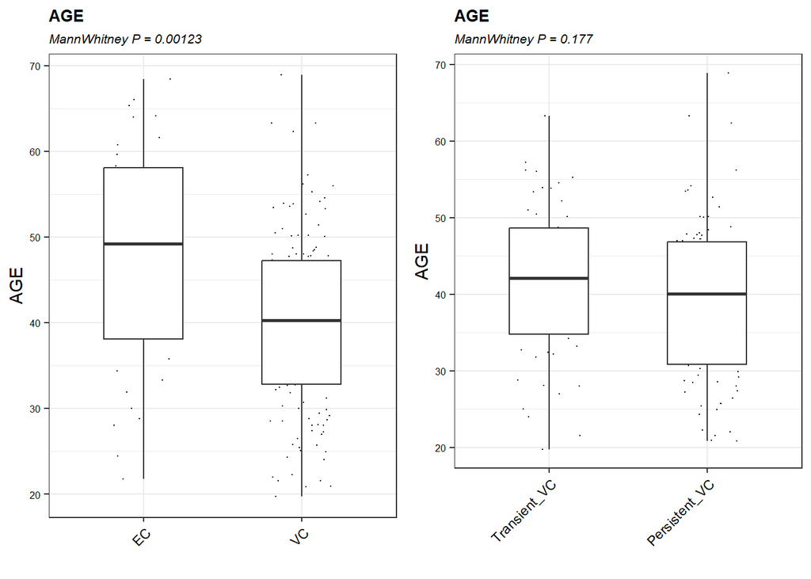

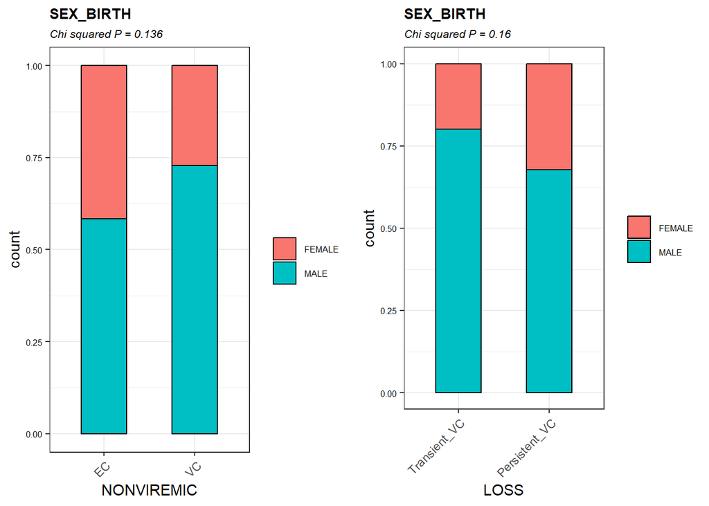

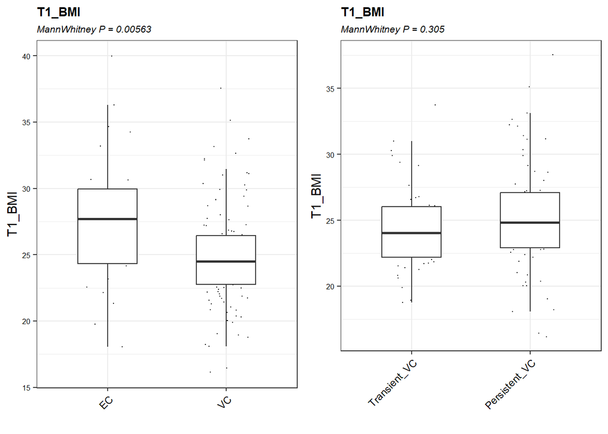

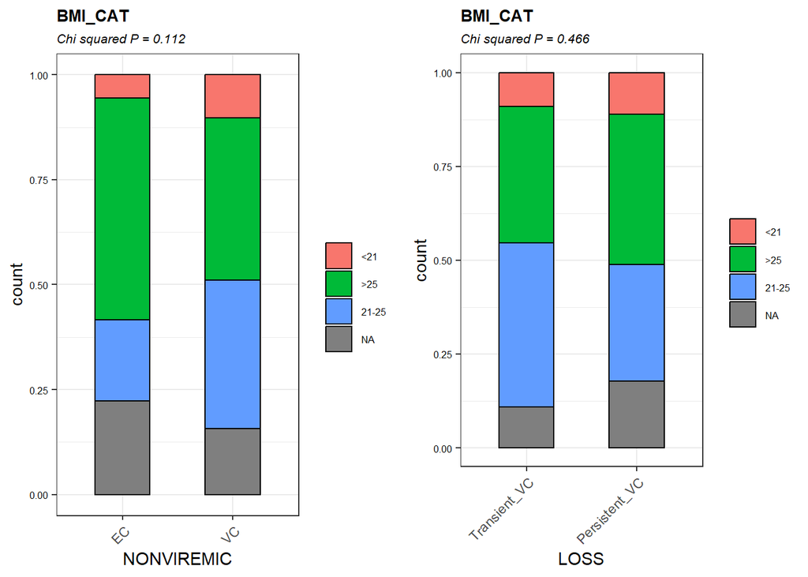

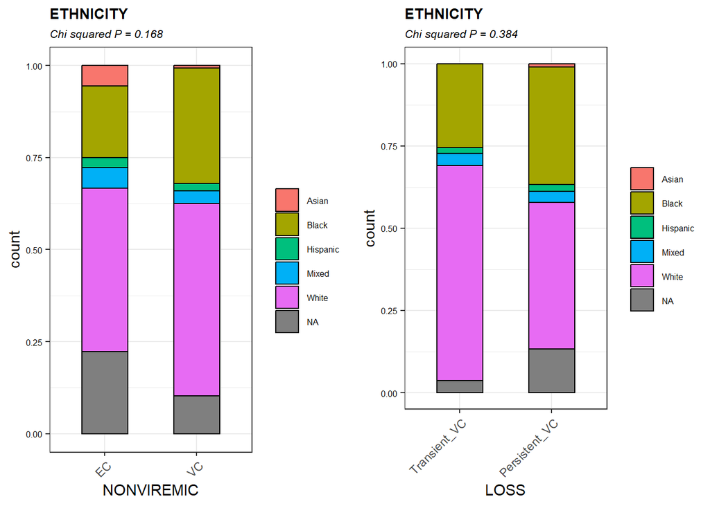

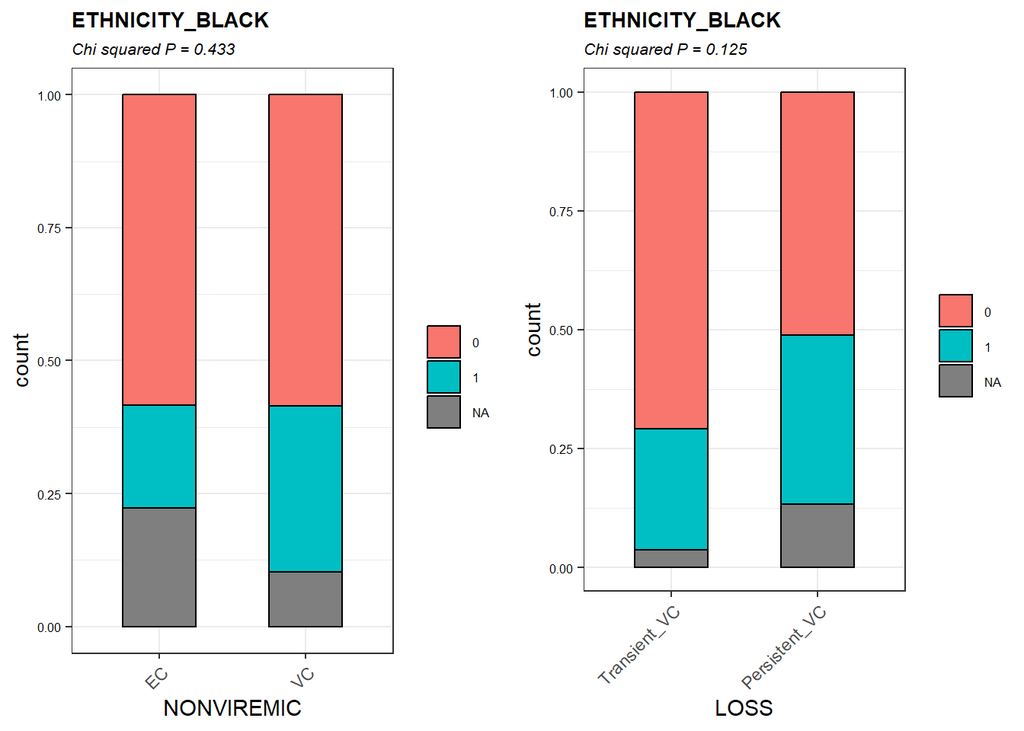

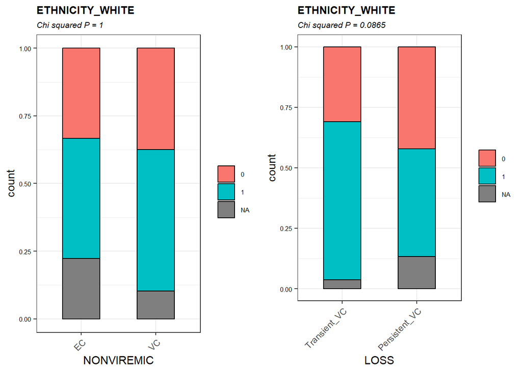

[figure not shown]

```r
library(ggplot2)
library(ggpubr)

S <- master_df
H <- vc

ggsave(paste0(working_dir, "Outputs/Supplements_Demographics_between_groups1.pdf"),
       suppressWarnings(gridExtra::grid.arrange(
# AGE
gridExtra::grid.arrange(
  ggplot(S,aes(x=NONVIREMIC, y=AGE)) +
      geom_jitter(shape=16, position=position_jitter(0.2),size = .1) +
      geom_boxplot(width = .5,outlier.shape = NA) +
      theme_bw() + theme(axis.text.x = element_text(colour="black", angle=45, hjust =1),
                         plot.subtitle = element_text(colour = "black",face = "italic", size = 8),plot.title = element_text(face = "bold", size = 10),axis.text.y = element_text(colour="black",size = 6),legend.text = element_text(size = 6))+
    xlab("") +
      ggtitle("AGE",subtitle = paste("MannWhitney P =",signif(wilcox.test(S$AGE~S$NONVIREMIC)$p.value,3))),
  ggplot(H,aes(x=LOSS, y=AGE)) +
      geom_jitter(shape=16, position=position_jitter(0.2),size = .1) +
      geom_boxplot(width = .5,outlier.shape = NA) +
      theme_bw() + theme(axis.text.x = element_text(colour="black", angle=45, hjust =1),
                         plot.subtitle = element_text(colour = "black",face = "italic", size = 8),plot.title = element_text(face = "bold", size = 10),axis.text.y = element_text(colour="black",size = 6),legend.text = element_text(size = 6))+
    xlab("") +
      ggtitle("AGE",subtitle = paste("MannWhitney P =",signif(wilcox.test(H$AGE~H$LOSS)$p.value,3))), ncol = 2),

# SEX
gridExtra::grid.arrange(
  ggplot(S, aes(NONVIREMIC))+
    geom_bar(aes(fill=as.factor(SEX)), position="fill", width = 0.5, color = "black") +
    theme_bw() + labs(fill="") + theme(axis.text.x = element_text(angle=45, hjust=1),plot.subtitle = element_text(colour = "black",face = "italic", size = 8),plot.title = element_text(face = "bold", size = 10),axis.text.y = element_text(colour="black",size = 6),legend.text = element_text(size = 6))+
    ggtitle("SEX_BIRTH",subtitle = paste("Chi squared P =",signif(chisq.test(S$SEX,S$NONVIREMIC)$p.value,3))),
  ggplot(H, aes(LOSS))+
    geom_bar(aes(fill=as.factor(SEX)), position="fill", width = 0.5, color = "black") +
    theme_bw() + labs(fill="") + theme(axis.text.x = element_text(angle=45, hjust=1),plot.subtitle = element_text(colour = "black",face = "italic", size = 8),plot.title = element_text(face = "bold", size = 10),axis.text.y = element_text(colour="black",size = 6),legend.text = element_text(size = 6))+
    ggtitle("SEX_BIRTH",subtitle = paste("Chi squared P =",signif(chisq.test(H$SEX,H$LOSS)$p.value,3))) , ncol = 2),

# BMI
gridExtra::grid.arrange(
  ggplot(S,aes(x=NONVIREMIC, y=T1_BMI)) +
      geom_jitter(shape=16, position=position_jitter(0.2),size = .1) +
      geom_boxplot(width = .5,outlier.shape = NA) +
      theme_bw() + theme(axis.text.x = element_text(colour="black", angle=45, hjust=1),plot.subtitle = element_text(colour = "black",face = "italic", size = 8),plot.title = element_text(face = "bold", size = 10),axis.text.y = element_text(colour="black",size = 6)) + xlab("") +
      ggtitle("T1_BMI",subtitle = paste("MannWhitney P =",signif(wilcox.test(S$T1_BMI~S$NONVIREMIC)$p.value,3))),
  ggplot(H,aes(x=LOSS, y=T1_BMI)) +
      geom_jitter(shape=16, position=position_jitter(0.2),size = .1) +
      geom_boxplot(width = .5,outlier.shape = NA) +
      theme_bw() + theme(axis.text.x = element_text(colour="black", angle=45, hjust=1),plot.subtitle = element_text(colour = "black",face = "italic", size = 8),plot.title = element_text(face = "bold", size = 10),axis.text.y = element_text(colour="black",size = 6)) + xlab("") +
      ggtitle("T1_BMI",subtitle = paste("MannWhitney P =",signif(wilcox.test(H$T1_BMI~H$LOSS)$p.value,3))), ncol = 2),

gridExtra::grid.arrange(
  ggplot(S, aes(NONVIREMIC))+
    geom_bar(aes(fill=as.factor(BMI_CAT)), position="fill", width = 0.5, color = "black") +
    theme_bw() + labs(fill="") + theme(axis.text.x = element_text(angle=45, hjust=1),plot.subtitle = element_text(colour = "black",face = "italic", size = 8),plot.title = element_text(face = "bold", size = 10),axis.text.y = element_text(colour="black",size = 6),legend.text = element_text(size = 6))+
    ggtitle("BMI_CAT",subtitle = paste("Chi squared P =",signif(chisq.test(S$BMI_CAT,S$NONVIREMIC)$p.value,3))),
  ggplot(H, aes(LOSS))+
    geom_bar(aes(fill=as.factor(BMI_CAT)), position="fill", width = 0.5, color = "black") +
    theme_bw() + labs(fill="") + theme(axis.text.x = element_text(angle=45, hjust=1),plot.subtitle = element_text(colour = "black",face = "italic", size = 8),plot.title = element_text(face = "bold", size = 10),axis.text.y = element_text(colour="black",size = 6),legend.text = element_text(size = 6))+
    ggtitle("BMI_CAT",subtitle = paste("Chi squared P =",signif(chisq.test(H$BMI_CAT,H$LOSS)$p.value,3))) , ncol = 2),

# ETHNICITY
gridExtra::grid.arrange(
  ggplot(S, aes(NONVIREMIC))+
    geom_bar(aes(fill=as.factor(ETHNICITY)), position="fill", width = 0.5, color = "black") +
    theme_bw() + labs(fill="") + theme(axis.text.x = element_text(angle=45, hjust=1),plot.subtitle = element_text(colour = "black",face = "italic", size = 8),plot.title = element_text(face = "bold", size = 10),axis.text.y = element_text(colour="black",size = 6),legend.text = element_text(size = 6))+
    ggtitle("ETHNICITY",subtitle = paste("Chi squared P =",signif(chisq.test(S$ETHNICITY,S$NONVIREMIC)$p.value,3))),
  ggplot(H, aes(LOSS))+
    geom_bar(aes(fill=as.factor(ETHNICITY)), position="fill", width = 0.5, color = "black") +
    theme_bw() + labs(fill="") + theme(axis.text.x = element_text(angle=45, hjust=1),plot.subtitle = element_text(colour = "black",face = "italic", size = 8),plot.title = element_text(face = "bold", size = 10),axis.text.y = element_text(colour="black",size = 6),legend.text = element_text(size = 6))+
    ggtitle("ETHNICITY",subtitle = paste("Chi squared P =",signif(chisq.test(H$ETHNICITY,H$LOSS)$p.value,3))) , ncol = 2),

gridExtra::grid.arrange(
  ggplot(S, aes(NONVIREMIC))+
    geom_bar(aes(fill=as.factor(ETHNICITY_BLACK)), position="fill", width = 0.5, color = "black") +
    theme_bw() + labs(fill="") + theme(axis.text.x = element_text(angle=45, hjust=1),plot.subtitle = element_text(colour = "black",face = "italic", size = 8),plot.title = element_text(face = "bold", size = 10),axis.text.y = element_text(colour="black",size = 6),legend.text = element_text(size = 6))+
    ggtitle("ETHNICITY_BLACK",subtitle = paste("Chi squared P =",signif(chisq.test(S$ETHNICITY_BLACK,S$NONVIREMIC)$p.value,3))),
  ggplot(H, aes(LOSS))+
    geom_bar(aes(fill=as.factor(ETHNICITY_BLACK)), position="fill", width = 0.5, color = "black") +
    theme_bw() + labs(fill="") + theme(axis.text.x = element_text(angle=45, hjust=1),plot.subtitle = element_text(colour = "black",face = "italic", size = 8),plot.title = element_text(face = "bold", size = 10),axis.text.y = element_text(colour="black",size = 6),legend.text = element_text(size = 6))+
    ggtitle("ETHNICITY_BLACK",subtitle = paste("Chi squared P =",signif(chisq.test(H$ETHNICITY_BLACK,H$LOSS)$p.value,3))) , ncol = 2),

gridExtra::grid.arrange(
  ggplot(S, aes(NONVIREMIC))+
    geom_bar(aes(fill=as.factor(ETHNICITY_WHITE)), position="fill", width = 0.5, color = "black") +
    theme_bw() + labs(fill="") + theme(axis.text.x = element_text(angle=45, hjust=1),plot.subtitle = element_text(colour = "black",face = "italic", size = 8),plot.title = element_text(face = "bold", size = 10),axis.text.y = element_text(colour="black",size = 6),legend.text = element_text(size = 6))+
    ggtitle("ETHNICITY_WHITE",subtitle = paste("Chi squared P =",signif(chisq.test(S$ETHNICITY_WHITE,S$NONVIREMIC)$p.value,3))),
  ggplot(H, aes(LOSS))+
    geom_bar(aes(fill=as.factor(ETHNICITY_WHITE)), position="fill", width = 0.5, color = "black") +
    theme_bw() + labs(fill="") + theme(axis.text.x = element_text(angle=45, hjust=1),plot.subtitle = element_text(colour = "black",face = "italic", size = 8),plot.title = element_text(face = "bold", size = 10),axis.text.y = element_text(colour="black",size = 6),legend.text = element_text(size = 6))+
    ggtitle("ETHNICITY_WHITE",subtitle = paste("Chi squared P =",signif(chisq.test(H$ETHNICITY_WHITE,H$LOSS)$p.value,3))) , ncol = 2),

# center
gridExtra::grid.arrange(
  ggplot(S, aes(NONVIREMIC))+
    geom_bar(aes(fill=as.factor(CENTER)), position="fill", width = 0.5, color = "black") +
    theme_bw() + labs(fill="") + theme(axis.text.x = element_text(angle=45, hjust=1),plot.subtitle = element_text(colour = "black",face = "italic", size = 8),plot.title = element_text(face = "bold", size = 10),axis.text.y = element_text(colour="black",size = 6),legend.text = element_text(size = 6))+
    ggtitle("CENTER",subtitle = paste("Chi squared P =",signif(chisq.test(S$CENTER,S$NONVIREMIC)$p.value,3))),
  ggplot(H, aes(LOSS))+
    geom_bar(aes(fill=as.factor(CENTER)), position="fill", width = 0.5, color = "black") +
    theme_bw() + labs(fill="") + theme(axis.text.x = element_text(angle=45, hjust=1),plot.subtitle = element_text(colour = "black",face = "italic", size = 8),plot.title = element_text(face = "bold", size = 10),axis.text.y = element_text(colour="black",size = 6),legend.text = element_text(size = 6))+
    ggtitle("CENTER",subtitle = paste("Chi squared P =",signif(chisq.test(H$CENTER,H$LOSS)$p.value,3))) , ncol = 2),

ncol = 2,nrow = 4)),
width = 210, height = 297, units = "mm") # A4 size )))
```

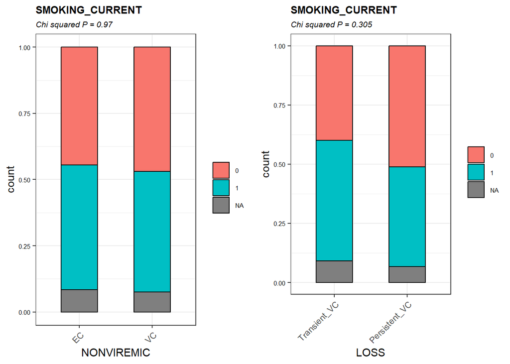

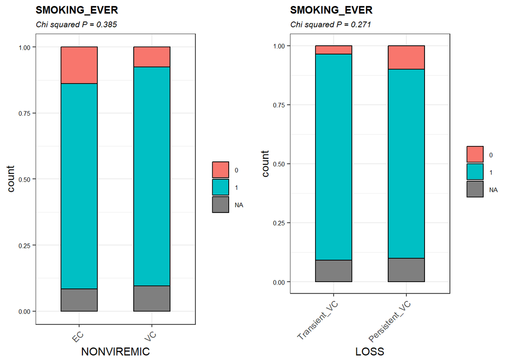

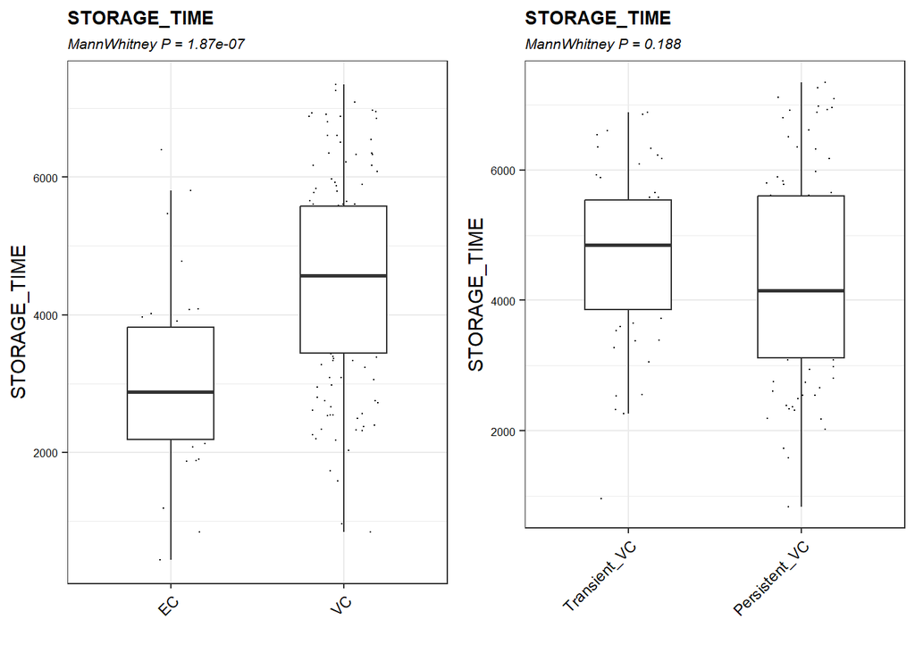

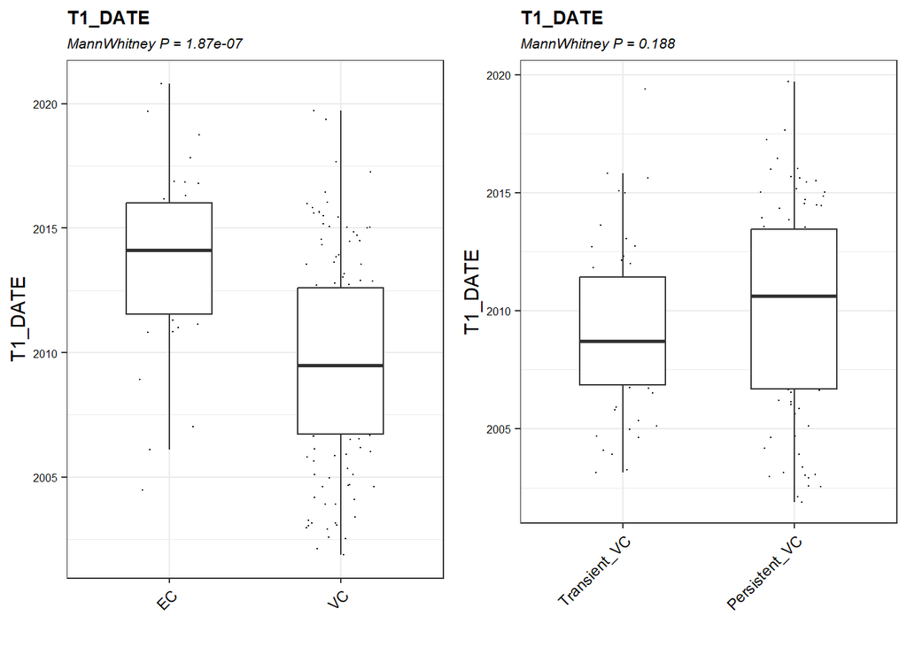

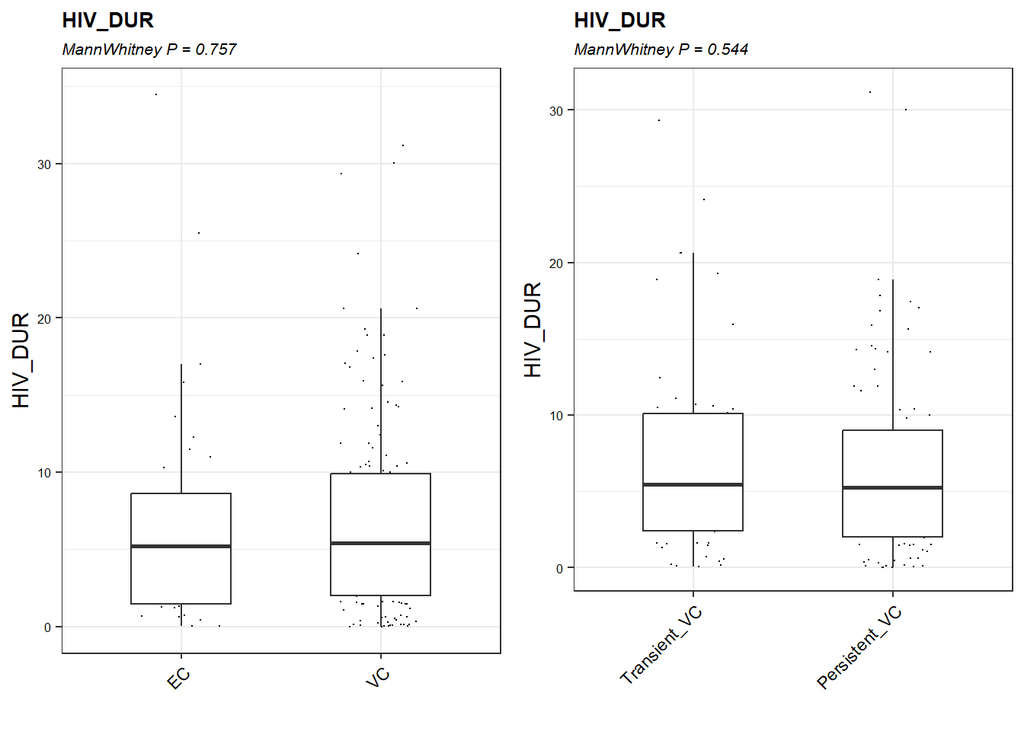

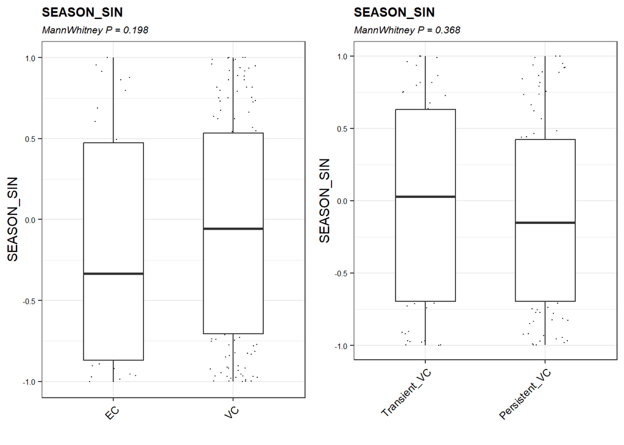

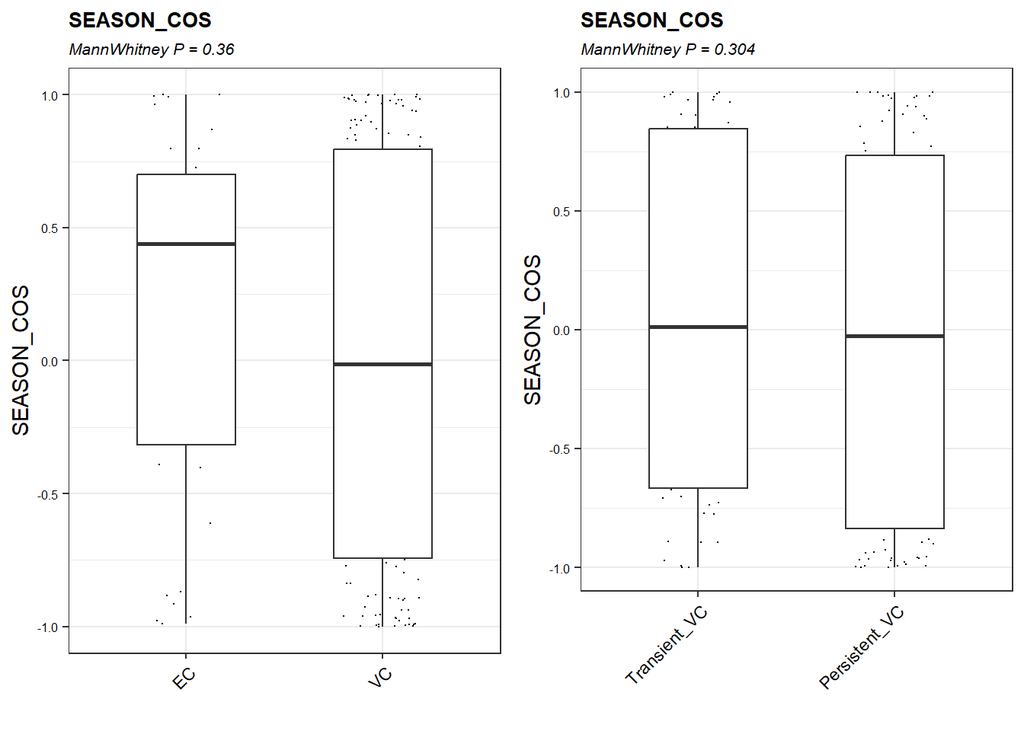

[figure not shown]

```r
###
ggsave(paste0(working_dir, "Outputs/Supplements_Demographics_between_groups2.pdf"),
       suppressWarnings(gridExtra::grid.arrange(
# SMOKING
gridExtra::grid.arrange(
  ggplot(S, aes(NONVIREMIC))+
    geom_bar(aes(fill=as.factor(SMOKING_CURRENT)), position="fill", width = 0.5, color = "black") +
    theme_bw() + labs(fill="") + theme(axis.text.x = element_text(angle=45, hjust=1),plot.subtitle = element_text(colour = "black",face = "italic", size = 8),plot.title = element_text(face = "bold", size = 10),axis.text.y = element_text(colour="black",size = 6),legend.text = element_text(size = 6))+
    ggtitle("SMOKING_CURRENT",subtitle = paste("Chi squared P =",signif(chisq.test(S$SMOKING_CURRENT,S$NONVIREMIC)$p.value,3))),
  ggplot(H, aes(LOSS))+
    geom_bar(aes(fill=as.factor(SMOKING_CURRENT)), position="fill", width = 0.5, color = "black") +
    theme_bw() + labs(fill="") + theme(axis.text.x = element_text(angle=45, hjust=1),plot.subtitle = element_text(colour = "black",face = "italic", size = 8),plot.title = element_text(face = "bold", size = 10),axis.text.y = element_text(colour="black",size = 6),legend.text = element_text(size = 6))+
    ggtitle("SMOKING_CURRENT",subtitle = paste("Chi squared P =",signif(chisq.test(H$SMOKING_CURRENT,H$LOSS)$p.value,3))) , ncol = 2),

gridExtra::grid.arrange(
  ggplot(S, aes(NONVIREMIC))+
    geom_bar(aes(fill=as.factor(SMOKING_EVER)), position="fill", width = 0.5, color = "black") +
    theme_bw() + labs(fill="") + theme(axis.text.x = element_text(angle=45, hjust=1),plot.subtitle = element_text(colour = "black",face = "italic", size = 8),plot.title = element_text(face = "bold", size = 10),axis.text.y = element_text(colour="black",size = 6),legend.text = element_text(size = 6))+
    ggtitle("SMOKING_EVER",subtitle = paste("Chi squared P =",signif(chisq.test(S$SMOKING_EVER,S$NONVIREMIC)$p.value,3))),
  ggplot(H, aes(LOSS))+
    geom_bar(aes(fill=as.factor(SMOKING_EVER)), position="fill", width = 0.5, color = "black") +
    theme_bw() + labs(fill="") + theme(axis.text.x = element_text(angle=45, hjust=1),plot.subtitle = element_text(colour = "black",face = "italic", size = 8),plot.title = element_text(face = "bold", size = 10),axis.text.y = element_text(colour="black",size = 6),legend.text = element_text(size = 6))+
    ggtitle("SMOKING_EVER",subtitle = paste("Chi squared P =",signif(chisq.test(H$SMOKING_EVER,H$LOSS)$p.value,3))) , ncol = 2),

# STORAGE_TIME
gridExtra::grid.arrange(
  ggplot(S,aes(x=NONVIREMIC, y=STORAGE_TIME)) +
      geom_jitter(shape=16, position=position_jitter(0.2),size = .1) +
      geom_boxplot(width = .5,outlier.shape = NA) +
      theme_bw() + theme(axis.text.x = element_text(colour="black", angle=45, hjust=1),plot.subtitle = element_text(colour = "black",face = "italic", size = 8),plot.title = element_text(face = "bold", size = 10),axis.text.y = element_text(colour="black",size = 6)) + xlab("") +
      ggtitle("STORAGE_TIME",subtitle = paste("MannWhitney P =",signif(wilcox.test(S$STORAGE_TIME~S$NONVIREMIC)$p.value,3))),
  ggplot(H,aes(x=LOSS, y=STORAGE_TIME)) +
      geom_jitter(shape=16, position=position_jitter(0.2),size = .1) +
      geom_boxplot(width = .5,outlier.shape = NA) +
      theme_bw() + theme(axis.text.x = element_text(colour="black", angle=45, hjust=1),plot.subtitle = element_text(colour = "black",face = "italic", size = 8),plot.title = element_text(face = "bold", size = 10),axis.text.y = element_text(colour="black",size = 6)) + xlab("") +
      ggtitle("STORAGE_TIME",subtitle = paste("MannWhitney P =",signif(wilcox.test(H$STORAGE_TIME~H$LOSS)$p.value,3))), ncol = 2),

# T1_DATE
gridExtra::grid.arrange(
  ggplot(S,aes(x=NONVIREMIC, y=T1_DATE)) +
      geom_jitter(shape=16, position=position_jitter(0.2),size = .1) +
      geom_boxplot(width = .5,outlier.shape = NA) +
      theme_bw() + theme(axis.text.x = element_text(colour="black", angle=45, hjust=1),plot.subtitle = element_text(colour = "black",face = "italic", size = 8),plot.title = element_text(face = "bold", size = 10),axis.text.y = element_text(colour="black",size = 6)) + xlab("") +
      ggtitle("T1_DATE",subtitle = paste("MannWhitney P =",signif(wilcox.test(as.numeric(S$T1_DATE)~S$NONVIREMIC)$p.value,3))),
  ggplot(H,aes(x=LOSS, y=T1_DATE)) +
      geom_jitter(shape=16, position=position_jitter(0.2),size = .1) +
      geom_boxplot(width = .5,outlier.shape = NA) +
      theme_bw() + theme(axis.text.x = element_text(colour="black", angle=45, hjust=1),plot.subtitle = element_text(colour = "black",face = "italic", size = 8),plot.title = element_text(face = "bold", size = 10),axis.text.y = element_text(colour="black",size = 6)) + xlab("") +
      ggtitle("T1_DATE",subtitle = paste("MannWhitney P =",signif(wilcox.test(as.numeric(H$T1_DATE)~H$LOSS)$p.value,3))), ncol = 2),

# HIV_DUR
gridExtra::grid.arrange(
  ggplot(S,aes(x=NONVIREMIC, y=HIV_DUR)) +
      geom_jitter(shape=16, position=position_jitter(0.2),size = .1) +
      geom_boxplot(width = .5,outlier.shape = NA) +
      theme_bw() + theme(axis.text.x = element_text(colour="black", angle=45, hjust=1),plot.subtitle = element_text(colour = "black",face = "italic", size = 8),plot.title = element_text(face = "bold", size = 10),axis.text.y = element_text(colour="black",size = 6)) + xlab("") +
      ggtitle("HIV_DUR",subtitle = paste("MannWhitney P =",signif(wilcox.test(S$HIV_DUR~S$NONVIREMIC)$p.value,3))),
  ggplot(H,aes(x=LOSS, y=HIV_DUR)) +
      geom_jitter(shape=16, position=position_jitter(0.2),size = .1) +
      geom_boxplot(width = .5,outlier.shape = NA) +
      theme_bw() + theme(axis.text.x = element_text(colour="black", angle=45, hjust=1),plot.subtitle = element_text(colour = "black",face = "italic", size = 8),plot.title = element_text(face = "bold", size = 10),axis.text.y = element_text(colour="black",size = 6)) + xlab("") +
      ggtitle("HIV_DUR",subtitle = paste("MannWhitney P =",signif(wilcox.test(H$HIV_DUR~H$LOSS)$p.value,3))), ncol = 2),

# SEASON
gridExtra::grid.arrange(
  ggplot(S,aes(x=NONVIREMIC, y=SEASON_SIN)) +
      geom_jitter(shape=16, position=position_jitter(0.2),size = .1) +
      geom_boxplot(width = .5,outlier.shape = NA) +
      theme_bw() + theme(axis.text.x = element_text(colour="black", angle=45, hjust=1),plot.subtitle = element_text(colour = "black",face = "italic", size = 8),plot.title = element_text(face = "bold", size = 10),axis.text.y = element_text(colour="black",size = 6)) + xlab("") +
      ggtitle("SEASON_SIN",subtitle = paste("MannWhitney P =",signif(wilcox.test(S$SEASON_SIN~S$NONVIREMIC)$p.value,3))),
  ggplot(H,aes(x=LOSS, y=SEASON_SIN)) +
      geom_jitter(shape=16, position=position_jitter(0.2),size = .1) +
      geom_boxplot(width = .5,outlier.shape = NA) +
      theme_bw() + theme(axis.text.x = element_text(colour="black", angle=45, hjust=1),plot.subtitle = element_text(colour = "black",face = "italic", size = 8),plot.title = element_text(face = "bold", size = 10),axis.text.y = element_text(colour="black",size = 6)) + xlab("") +
      ggtitle("SEASON_SIN",subtitle = paste("MannWhitney P =",signif(wilcox.test(H$SEASON_SIN~H$LOSS)$p.value,3))), ncol = 2),

gridExtra::grid.arrange(
  ggplot(S,aes(x=NONVIREMIC, y=SEASON_COS)) +
      geom_jitter(shape=16, position=position_jitter(0.2),size = .1) +
      geom_boxplot(width = .5,outlier.shape = NA) +
      theme_bw() + theme(axis.text.x = element_text(colour="black", angle=45, hjust=1),plot.subtitle = element_text(colour = "black",face = "italic", size = 8),plot.title = element_text(face = "bold", size = 10),axis.text.y = element_text(colour="black",size = 6)) + xlab("") +
      ggtitle("SEASON_COS",subtitle = paste("MannWhitney P =",signif(wilcox.test(S$SEASON_COS~S$NONVIREMIC)$p.value,3))),
  ggplot(H,aes(x=LOSS, y=SEASON_COS)) +
      geom_jitter(shape=16, position=position_jitter(0.2),size = .1) +
      geom_boxplot(width = .5,outlier.shape = NA) +
      theme_bw() + theme(axis.text.x = element_text(colour="black", angle=45, hjust=1),plot.subtitle = element_text(colour = "black",face = "italic", size = 8),plot.title = element_text(face = "bold", size = 10),axis.text.y = element_text(colour="black",size = 6)) + xlab("") +
      ggtitle("SEASON_COS",subtitle = paste("MannWhitney P =",signif(wilcox.test(H$SEASON_COS~H$LOSS)$p.value,3))), ncol = 2),

gridExtra::grid.arrange(
  ggplot(S, aes(NONVIREMIC))+
    geom_bar(aes(fill=as.factor(SEASON_CAT)), position="fill", width = 0.5, color = "black") +
    theme_bw() + labs(fill="") + theme(axis.text.x = element_text(angle=45, hjust=1),plot.subtitle = element_text(colour = "black",face = "italic", size = 8),plot.title = element_text(face = "bold", size = 10),axis.text.y = element_text(colour="black",size = 6),legend.text = element_text(size = 6))+
    ggtitle("SEASON_CAT",subtitle = paste("Chi squared P =",signif(chisq.test(S$SEASON_CAT,S$NONVIREMIC)$p.value,3))),
  ggplot(H, aes(LOSS))+
    geom_bar(aes(fill=as.factor(SEASON_CAT)), position="fill", width = 0.5, color = "black") +
    theme_bw() + labs(fill="") + theme(axis.text.x = element_text(angle=45, hjust=1),plot.subtitle = element_text(colour = "black",face = "italic", size = 8),plot.title = element_text(face = "bold", size = 10),axis.text.y = element_text(colour="black",size = 6),legend.text = element_text(size = 6))+
    ggtitle("SEASON_CAT",subtitle = paste("Chi squared P =",signif(chisq.test(H$SEASON_CAT,H$LOSS)$p.value,3))) , ncol = 2),


ncol = 2,nrow = 4)),
width = 210, height = 297, units = "mm") # A4 size )))
```

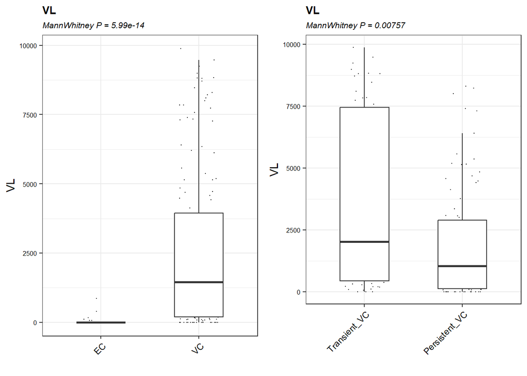

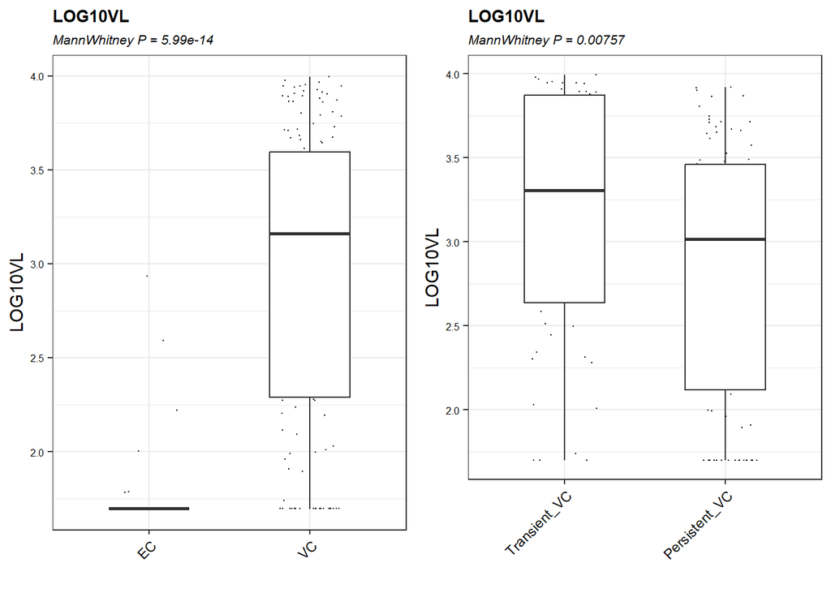

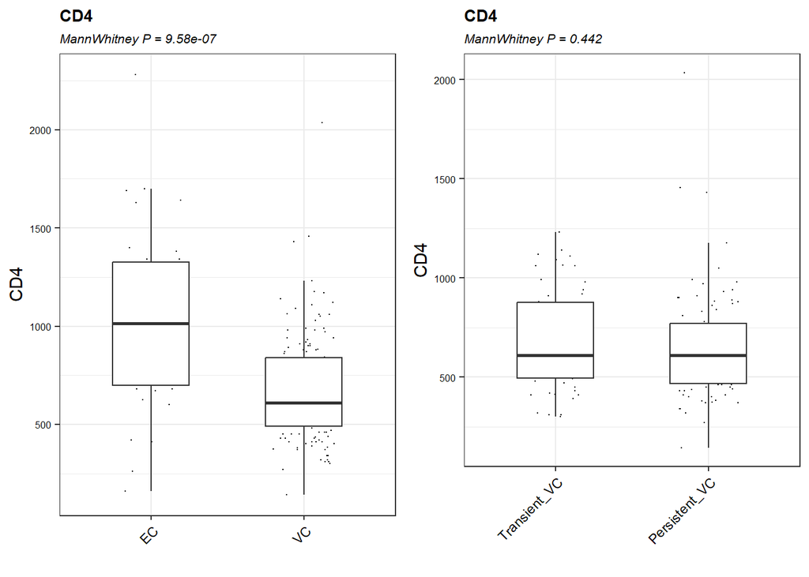

[figure not shown]

```r
###
ggsave(paste0(working_dir, "Outputs/Supplements_Demographics_between_groups3.pdf"),
       suppressWarnings(gridExtra::grid.arrange(
# VL
gridExtra::grid.arrange(
  ggplot(S,aes(x=NONVIREMIC, y=VL)) +
      geom_jitter(shape=16, position=position_jitter(0.2),size = .1) +
      geom_boxplot(width = .5,outlier.shape = NA) +
      theme_bw() + theme(axis.text.x = element_text(colour="black", angle=45, hjust=1),plot.subtitle = element_text(colour = "black",face = "italic", size = 8),plot.title = element_text(face = "bold", size = 10),axis.text.y = element_text(colour="black",size = 6)) + xlab("") +
      ggtitle("VL",subtitle = paste("MannWhitney P =",signif(wilcox.test(S$VL~S$NONVIREMIC)$p.value,3))),
  ggplot(H,aes(x=LOSS, y=VL)) +
      geom_jitter(shape=16, position=position_jitter(0.2),size = .1) +
      geom_boxplot(width = .5,outlier.shape = NA) +
      theme_bw() + theme(axis.text.x = element_text(colour="black", angle=45, hjust=1),plot.subtitle = element_text(colour = "black",face = "italic", size = 8),plot.title = element_text(face = "bold", size = 10),axis.text.y = element_text(colour="black",size = 6)) + xlab("") +
      ggtitle("VL",subtitle = paste("MannWhitney P =",signif(wilcox.test(H$VL~H$LOSS)$p.value,3))), ncol = 2),

gridExtra::grid.arrange(
  ggplot(S,aes(x=NONVIREMIC, y=LOG10VL)) +
      geom_jitter(shape=16, position=position_jitter(0.2),size = .1) +
      geom_boxplot(width = .5,outlier.shape = NA) +
      theme_bw() + theme(axis.text.x = element_text(colour="black", angle=45, hjust=1),plot.subtitle = element_text(colour = "black",face = "italic", size = 8),plot.title = element_text(face = "bold", size = 10),axis.text.y = element_text(colour="black",size = 6)) + xlab("") +
      ggtitle("LOG10VL",subtitle = paste("MannWhitney P =",signif(wilcox.test(S$LOG10VL~S$NONVIREMIC)$p.value,3))),
  ggplot(H,aes(x=LOSS, y=LOG10VL)) +
      geom_jitter(shape=16, position=position_jitter(0.2),size = .1) +
      geom_boxplot(width = .5,outlier.shape = NA) +
      theme_bw() + theme(axis.text.x = element_text(colour="black", angle=45, hjust=1),plot.subtitle = element_text(colour = "black",face = "italic", size = 8),plot.title = element_text(face = "bold", size = 10),axis.text.y = element_text(colour="black",size = 6)) + xlab("") +
      ggtitle("LOG10VL",subtitle = paste("MannWhitney P =",signif(wilcox.test(H$LOG10VL~H$LOSS)$p.value,3))), ncol = 2),

# CD4
gridExtra::grid.arrange(
  ggplot(S,aes(x=NONVIREMIC, y=CD4)) +
      geom_jitter(shape=16, position=position_jitter(0.2),size = .1) +
      geom_boxplot(width = .5,outlier.shape = NA) +
      theme_bw() + theme(axis.text.x = element_text(colour="black", angle=45, hjust=1),plot.subtitle = element_text(colour = "black",face = "italic", size = 8),plot.title = element_text(face = "bold", size = 10),axis.text.y = element_text(colour="black",size = 6)) + xlab("") +
      ggtitle("CD4",subtitle = paste("MannWhitney P =",signif(wilcox.test(S$CD4~S$NONVIREMIC)$p.value,3))),
  ggplot(H,aes(x=LOSS, y=CD4)) +
      geom_jitter(shape=16, position=position_jitter(0.2),size = .1) +
      geom_boxplot(width = .5,outlier.shape = NA) +
      theme_bw() + theme(axis.text.x = element_text(colour="black", angle=45, hjust=1),plot.subtitle = element_text(colour = "black",face = "italic", size = 8),plot.title = element_text(face = "bold", size = 10),axis.text.y = element_text(colour="black",size = 6)) + xlab("") +
      ggtitle("CD4",subtitle = paste("MannWhitney P =",signif(wilcox.test(H$CD4~H$LOSS)$p.value,3))), ncol = 2),

gridExtra::grid.arrange(
  ggplot(S,aes(x=NONVIREMIC, y=CD4NADIR)) +
      geom_jitter(shape=16, position=position_jitter(0.2),size = .1) +
      geom_boxplot(width = .5,outlier.shape = NA) +
      theme_bw() + theme(axis.text.x = element_text(colour="black", angle=45, hjust=1),plot.subtitle = element_text(colour = "black",face = "italic", size = 8),plot.title = element_text(face = "bold", size = 10),axis.text.y = element_text(colour="black",size = 6)) + xlab("") +
      ggtitle("CD4NADIR",subtitle = paste("MannWhitney P =",signif(wilcox.test(S$CD4NADIR~S$NONVIREMIC)$p.value,3))),
  ggplot(H,aes(x=LOSS, y=CD4NADIR)) +
      geom_jitter(shape=16, position=position_jitter(0.2),size = .1) +
      geom_boxplot(width = .5,outlier.shape = NA) +
      theme_bw() + theme(axis.text.x = element_text(colour="black", angle=45, hjust=1),plot.subtitle = element_text(colour = "black",face = "italic", size = 8),plot.title = element_text(face = "bold", size = 10),axis.text.y = element_text(colour="black",size = 6)) + xlab("") +
      ggtitle("CD4NADIR",subtitle = paste("MannWhitney P =",signif(wilcox.test(H$CD4NADIR~H$LOSS)$p.value,3))), ncol = 2),


ncol = 2,nrow = 4)),
width = 210, height = 297, units = "mm") # A4 size )))
```

```r
rm(S,H)
```

## 0.4 Interpretation covariates

Between EC and VC: * AGE is slightly higher in EC * T1_BMI is slightly higher in EC * CENTER is more often MSZ and RAD in EC, but less often EMC and no LUMC * STORAGE_TIME is shorter in EC (and T1_DATE more recent) * [VL and LOG10VL are by definition lower in EC] * [CD4 and CD4NADIR are higher in EC]

Between Transient_VC and Persistent_VC: * CENTER trends to more often OLVG in Transient_VC * ETHNICITY_WHITE trends to more in Transient_VC * VL and LOG10VL are slightly higher in Transient_VC

Importantly, the other covariates are equally distributed and correction for those is strictly not needed, although a sensitivity analysis is usually good to confirm.

Now, the question is whether these demographics significantly influence protein expression, which will be determines by correlating covariates with principle components, in the DifferentialExpression script.

# 1 Clean data 2000HIV (Validation cohort)

Read data 2000HIV and prepare data for comparison.

From the dataset we read, there are only “EC_persistent_viremic_noART” and “EC_persistent_nonviremic_noART” of patients that are not already in our ATHENA dataset.

```r
##### Read Olink comparison 1 file #####
master_df <-  openxlsx::read.xlsx(paste0(working_dir,"Inputs/Olink_2000HIV_EC_vs_VC_1910samp_2409_Prots_masterdata.xlsx"))

table(master_df$EC_combined)
```

```
##
## EC_persistent_nonviremic_noART    EC_persistent_viremic_noART
##                             14                              5
```

```r
  # EC_persistent_nonviremic_noART
  #                             14
  #  EC_persistent_viremic_noART
  #                            5
```

```r
library(table1)

df_m <- master_df %>%
  mutate(EC_combined = ifelse(EC_combined == "EC_persistent_viremic_noART","ARTnaive_VC","EC"))%>%
  mutate_at(c("EC_combined","CENTER","SEX_BIRTH","SMOKING_CURRENT", "ETHNICITY", "PANDEMIC_BEFOREAFTER","COVID19","COVID_VACC"),funs(factor)) %>%
  mutate(VL_numeric = ifelse(is.na(VL_LATEST_OTHER), VL_LATEST,VL_LATEST_OTHER),.after=VL_LATEST_OTHER) %>%
  mutate(CD4_NADIR = CD4_NADIR * 1000, CD4_LATEST = CD4_LATEST * 1000)
summary(as.factor(df_m$EC_combined))
```

```
## ARTnaive_VC          EC
##           5          14
```

```r
saveRDS(df_m %>% select(-ID), paste0(working_dir, "Outputs/Validation2000HIVOlink_EC_vs_VC_Cleaned.rds"))
######
```

```r
# run table1 function for summary statistics of overall cohort
table1(~ AGE +
         CENTER +
         SEX_BIRTH +
         BMI_BASELINE +
         SMOKING_CURRENT +
         ETHNICITY +
         CD4_LATEST +
         CD4_NADIR +
         VL_numeric +
         HIV_DURATION +
         PANDEMIC_BEFOREAFTER + COVID19 + COVID_VACC | EC_combined  , data=df_m)
```

|  | ARTnaive_VC (N=5) | EC (N=14) | Overall (N=19) |
| --- | --- | --- | --- |
| AGE |  |  |  |
| Mean (SD) | 49.0 (15.4) | 49.9 (13.8) | 49.7 (13.8) |
| Median [Min, Max] | 43.0 [34.0, 70.0] | 51.0 [28.0, 74.0] | 51.0 [28.0, 74.0] |
| CENTER |  |  |  |
| EMC | 4 (80.0%) | 7 (50.0%) | 11 (57.9%) |
| OLV | 1 (20.0%) | 6 (42.9%) | 7 (36.8%) |
| RUMC | 0 (0%) | 1 (7.1%) | 1 (5.3%) |
| SEX_BIRTH |  |  |  |
| 0 | 3 (60.0%) | 9 (64.3%) | 12 (63.2%) |
| 1 | 2 (40.0%) | 5 (35.7%) | 7 (36.8%) |
| BMI_BASELINE |  |  |  |
| Mean (SD) | 24.9 (3.75) | 28.1 (8.14) | 27.3 (7.29) |
| Median [Min, Max] | 25.0 [19.7, 30.1] | 26.5 [19.3, 46.2] | 25.7 [19.3, 46.2] |
| SMOKING_CURRENT |  |  |  |
| 0 | 4 (80.0%) | 10 (71.4%) | 14 (73.7%) |
| 1 | 1 (20.0%) | 4 (28.6%) | 5 (26.3%) |
| ETHNICITY |  |  |  |
| Black | 1 (20.0%) | 0 (0%) | 1 (5.3%) |
| Hispanic | 0 (0%) | 1 (7.1%) | 1 (5.3%) |
| Mixed | 1 (20.0%) | 2 (14.3%) | 3 (15.8%) |
| White | 3 (60.0%) | 11 (78.6%) | 14 (73.7%) |
| CD4_LATEST |  |  |  |
| Mean (SD) | 724 (307) | 1070 (739) | 977 (663) |
| Median [Min, Max] | 530 [471, 1130] | 726 [556, 3170] | 693 [471, 3170] |
| CD4_NADIR |  |  |  |
| Mean (SD) | 508 (188) | 743 (509) | 681 (454) |
| Median [Min, Max] | 450 [290, 770] | 534 [380, 2210] | 487 [290, 2210] |
| VL_numeric |  |  |  |
| Mean (SD) | 475 (417) | 12.4 (27.5) | 134 (288) |
| Median [Min, Max] | 229 [147, 1110] | 0 [0, 92.0] | 0 [0, 1110] |
| HIV_DURATION |  |  |  |
| Mean (SD) | 17.3 (7.93) | 13.6 (7.64) | 14.5 (7.68) |
| Median [Min, Max] | 15.0 [11.4, 31.0] | 12.2 [6.40, 36.0] | 13.2 [6.40, 36.0] |
| PANDEMIC_BEFOREAFTER |  |  |  |
| 0 | 1 (20.0%) | 0 (0%) | 1 (5.3%) |
| 1 | 4 (80.0%) | 14 (100%) | 18 (94.7%) |
| COVID19 |  |  |  |
| 0 | 5 (100%) | 11 (78.6%) | 16 (84.2%) |
| 1 | 0 (0%) | 3 (21.4%) | 3 (15.8%) |
| COVID_VACC |  |  |  |
| 0 | 3 (60.0%) | 6 (42.9%) | 9 (47.4%) |
| 1 | 2 (40.0%) | 8 (57.1%) | 10 (52.6%) |

```r
#Statistics
df_lib <- df_m
names(df_lib)[1:150]
```

```
##   [1] "ID"                             "EC_yesno"
##   [3] "EC_lost"                        "EC_vir"
##   [5] "EC_ART"                         "EC_combined"
##   [7] "CENTER"                         "COHORT"
##   [9] "SEX_BIRTH"                      "GEN"
##  [11] "AGE"                            "DATE_VISIT"
##  [13] "Days_since_Jan2019"             "SEASON_SIN"
##  [15] "SEASON_COS"                     "PANDEMIC_BEFOREAFTER"
##  [17] "ETHNICITY"                      "AB_1M"
##  [19] "MED.Anticoagulants"             "MED.Antidiabetics"
##  [21] "MED.Cholesterol_lowering"       "MED.Antihypertensiva"
##  [23] "MED.Antiinflammatory"           "MED.Antivirals"
##  [25] "MED.Psychotropic"               "MED.VitaminD"
##  [27] "MED.Antimycotics"               "MED.Other"
##  [29] "MED.No_other"                   "MED_AC.VKA"
```

[output cut: 60 more lines]

```r
#wilcoxon/ttest
modelList<-list()
for(i in c(11,79,84:85,142,144)){
  fmla <- formula(paste(names(df_lib)[i], " ~ EC_combined"))
  modelList[[i]]<-wilcox.test(fmla, data = df_lib, paired = FALSE)
}
modelList
```

```
## [[1]]
## NULL
##
## [[2]]
## NULL
##
## [[3]]
## NULL
##
## [[4]]
## NULL
##
## [[5]]
## NULL
##
## [[6]]
## NULL
##
## [[7]]
## NULL
##
## [[8]]
## NULL
##
## [[9]]
## NULL
##
## [[10]]
## NULL
##
## [[11]]
##
##  Wilcoxon rank sum test with continuity correction
##
## data:  AGE by EC_combined
## W = 32.5, p-value = 0.8528
## alternative hypothesis: true location shift is not equal to 0
##
##
## [[12]]
```

[output cut: 411 more lines]

```
## data:  VL_numeric by EC_combined
## W = 70, p-value = 0.0003772
## alternative hypothesis: true location shift is not equal to 0
##
##
## [[143]]
## NULL
##
## [[144]]
##
##  Wilcoxon rank sum exact test
##
## data:  CD4_LATEST by EC_combined
## W = 18, p-value = 0.1299
## alternative hypothesis: true location shift is not equal to 0
```

```r
#chisquare
# df_lib[,c(6,7,9,17,16,66,71,62)] %>%
#   dplyr::summarise_each(funs(chisq.test(.,
#                                  df_lib$EC_combined)$p.value), -one_of("EC_combined"))
```

### 1.0.1 ADDENDUM 2/12/2024 UPDATE TABLE 1

```r
# Custom rendering function
rndr <- function(x, name, ...) {
  if (is.numeric(x)) {
    med_iqr <- function(x) {
      iqr <- quantile(x, c(0.25, 0.75), na.rm = TRUE)
      sprintf("%.1f [%.1f, %.1f]", median(x, na.rm = TRUE), iqr[1], iqr[2])
    }
    return(med_iqr(x))
  } else {
    return(render.categorical.default(x))
  }
}

# run table1 function for summary statistics of overall cohort
table1(~ AGE +
         CENTER +
         SEX_BIRTH +
         BMI_BASELINE +
         SMOKING_CURRENT +
         ETHNICITY +
         CD4_LATEST +
         CD4_NADIR +
         VL_numeric +
         HIV_DURATION +
         PANDEMIC_BEFOREAFTER + COVID19 + COVID_VACC | EC_combined, data=df_m, render = rndr)
```

|  | ARTnaive_VC (N=5) | EC (N=14) | Overall (N=19) |
| --- | --- | --- | --- |
| AGE | 43.0 [38.0, 60.0] | 51.0 [38.2, 61.0] | 51.0 [38.0, 62.0] |
| CENTER |  |  |  |
| EMC | 4 (80.0%) | 7 (50.0%) | 11 (57.9%) |
| OLV | 1 (20.0%) | 6 (42.9%) | 7 (36.8%) |
| RUMC | 0 (0%) | 1 (7.1%) | 1 (5.3%) |
| SEX_BIRTH |  |  |  |
| 0 | 3 (60.0%) | 9 (64.3%) | 12 (63.2%) |
| 1 | 2 (40.0%) | 5 (35.7%) | 7 (36.8%) |
| BMI_BASELINE | 25.0 [23.9, 25.7] | 26.5 [21.6, 32.0] | 25.7 [21.9, 29.1] |
| SMOKING_CURRENT |  |  |  |
| 0 | 4 (80.0%) | 10 (71.4%) | 14 (73.7%) |
| 1 | 1 (20.0%) | 4 (28.6%) | 5 (26.3%) |
| ETHNICITY |  |  |  |
| Black | 1 (20.0%) | 0 (0%) | 1 (5.3%) |
| Hispanic | 0 (0%) | 1 (7.1%) | 1 (5.3%) |
| Mixed | 1 (20.0%) | 2 (14.3%) | 3 (15.8%) |
| White | 3 (60.0%) | 11 (78.6%) | 14 (73.7%) |
| CD4_LATEST | 530.0 [510.0, 980.0] | 726.0 [610.0, 1178.8] | 693.0 [583.5, 1115.0] |
| CD4_NADIR | 450.0 [410.0, 620.0] | 534.0 [461.2, 734.2] | 487.0 [450.0, 709.5] |
| VL_numeric | 229.0 [198.0, 693.0] | 0.0 [0.0, 0.0] | 0.0 [0.0, 119.5] |
| HIV_DURATION | 15.0 [12.4, 16.6] | 12.2 [8.8, 15.8] | 13.2 [10.0, 16.5] |
| PANDEMIC_BEFOREAFTER |  |  |  |
| 0 | 1 (20.0%) | 0 (0%) | 1 (5.3%) |
| 1 | 4 (80.0%) | 14 (100%) | 18 (94.7%) |
| COVID19 |  |  |  |
| 0 | 5 (100%) | 11 (78.6%) | 16 (84.2%) |
| 1 | 0 (0%) | 3 (21.4%) | 3 (15.8%) |
| COVID_VACC |  |  |  |
| 0 | 3 (60.0%) | 6 (42.9%) | 9 (47.4%) |
| 1 | 2 (40.0%) | 8 (57.1%) | 10 (52.6%) |

# 2 Cleaning Paired Samples Data: Effect of Time & ART

```r
master_df <-  openxlsx::read.xlsx(paste0(working_dir, "Inputs/Olink_SHM_ECVC_preART_vs_postART_206samp_2420Prots_masterdata.xlsx"))%>%
  mutate_at(c(2,3,5,11,16,17,22,23,32:36), as.factor)%>%
  #filter(!NONVIREMIC==1)%>%
  mutate(STATUS=  ifelse(STATUS == "T1","preART","postART"))

table(master_df$STATUS)
```

```
##
## postART  preART
##     103     103
```

```r
# postART  preART
#      103      103
```

## 2.1 Patient characteristics before and after ART (paired samples)

```r
##### Summary statistics #####
library(table1)
library(tidyr)

df_m <- master_df %>%
  drop_na(LOSS) %>%
  #filter(!NONVIREMIC==1) %>%
  dplyr::mutate(
    NONVIREMIC = ifelse(NONVIREMIC==1,"EC","VC"),
    LOSS = ifelse(LOSS==1,"Transient","Persistent"),
    nonviremic_loss = paste0(NONVIREMIC,"_",LOSS),.after=T2_PI)%>%
  mutate_at(c("STATUS","CENTER","SEX","SMOKING_CURRENT_T1","SMOKING_EVER_T1",
              "NONVIREMIC","ETHNICITY","T2_REGIMEN","T2_TENOFOVIR", "LOSS",
              "T2_TENOFOVIR_SPEC","T2_INSTI","T2_NNRTI","T2_PI","nonviremic_loss"),funs(factor))
df_m$STATUS <- factor(df_m$STATUS, levels = c("preART","postART"))

# run table1 function for summary statistics of overall cohort
  table1(~ AGE +
           SEX +
           BMI +
           CENTER +
           SMOKING_CURRENT_T1 +
           #SMOKING_EVER_T1 +
           ETHNICITY +
           CD4_LATEST +
           T1_CD4NADIR +
           VL +
           VL_ZENITH +
           HIV_DUR_T1 +
           T2_VL_UNDETECT +
           #T2_INTERRUPTED_ART +
           T2_ART_DUR_DAYS +
           #T2_REGIMEN +
           #T2_TENOFOVIR +
           #T2_TENOFOVIR_SPEC +
           T2_INSTI + T2_NNRTI + T2_PI +
           Storage_time  +
           FU_TOTAL
           | nonviremic_loss + STATUS, data=df_m)
```

|  | EC_Persistent preART (N=9) | EC_Persistent postART (N=9) | VC_Persistent preART (N=57) | VC_Persistent postART (N=57) | VC_Transient preART (N=36) | VC_Transient postART (N=36) | Overall preART (N=102) | Overall postART (N=102) |
| --- | --- | --- | --- | --- | --- | --- | --- | --- |
| AGE |  |  |  |  |  |  |  |  |
| Mean (SD) | 47.0 (13.1) | 55.2 (13.7) | 39.6 (10.0) | 49.0 (10.3) | 41.7 (10.4) | 52.5 (9.87) | 41.0 (10.6) | 50.8 (10.6) |
| Median [Min, Max] | 49.5 [24.4, 64.1] | 60.2 [27.7, 70.6] | 39.7 [20.9, 68.9] | 46.9 [23.4, 77.9] | 42.6 [21.5, 63.3] | 52.1 [36.7, 75.3] | 40.2 [20.9, 68.9] | 49.8 [23.4, 77.9] |
| SEX |  |  |  |  |  |  |  |  |
| FEMALE | 2 (22.2%) | 2 (22.2%) | 17 (29.8%) | 17 (29.8%) | 9 (25.0%) | 9 (25.0%) | 28 (27.5%) | 28 (27.5%) |
| MALE | 7 (77.8%) | 7 (77.8%) | 40 (70.2%) | 40 (70.2%) | 27 (75.0%) | 27 (75.0%) | 74 (72.5%) | 74 (72.5%) |
| BMI |  |  |  |  |  |  |  |  |
| Mean (SD) | 26.1 (4.08) | NA (NA) | 25.1 (4.07) | NA (NA) | 25.0 (3.31) | NA (NA) | 25.2 (3.78) | NA (NA) |
| Median [Min, Max] | 25.5 [21.3, 34.2] | NA [NA, NA] | 24.7 [16.2, 35.1] | NA [NA, NA] | 24.3 [18.8, 33.7] | NA [NA, NA] | 24.7 [16.2, 35.1] | NA [NA, NA] |
| Missing | 1 (11.1%) | 9 (100%) | 11 (19.3%) | 57 (100%) | 5 (13.9%) | 36 (100%) | 17 (16.7%) | 102 (100%) |
| CENTER |  |  |  |  |  |  |  |  |
| EMC | 1 (11.1%) | 1 (11.1%) | 19 (33.3%) | 19 (33.3%) | 8 (22.2%) | 8 (22.2%) | 28 (27.5%) | 28 (27.5%) |
| LUMC | 0 (0%) | 0 (0%) | 3 (5.3%) | 3 (5.3%) | 1 (2.8%) | 1 (2.8%) | 4 (3.9%) | 4 (3.9%) |
| MSZ | 2 (22.2%) | 2 (22.2%) | 7 (12.3%) | 7 (12.3%) | 0 (0%) | 0 (0%) | 9 (8.8%) | 9 (8.8%) |
| OLVG | 5 (55.6%) | 5 (55.6%) | 21 (36.8%) | 21 (36.8%) | 23 (63.9%) | 23 (63.9%) | 49 (48.0%) | 49 (48.0%) |
| RAD | 1 (11.1%) | 1 (11.1%) | 4 (7.0%) | 4 (7.0%) | 0 (0%) | 0 (0%) | 5 (4.9%) | 5 (4.9%) |
| UMCU | 0 (0%) | 0 (0%) | 3 (5.3%) | 3 (5.3%) | 4 (11.1%) | 4 (11.1%) | 7 (6.9%) | 7 (6.9%) |
| SMOKING_CURRENT_T1 |  |  |  |  |  |  |  |  |
| 0 | 3 (33.3%) | 4 (44.4%) | 27 (47.4%) | 33 (57.9%) | 17 (47.2%) | 22 (61.1%) | 47 (46.1%) | 59 (57.8%) |
| 1 | 5 (55.6%) | 4 (44.4%) | 27 (47.4%) | 20 (35.1%) | 15 (41.7%) | 10 (27.8%) | 47 (46.1%) | 34 (33.3%) |
| Missing | 1 (11.1%) | 1 (11.1%) | 3 (5.3%) | 4 (7.0%) | 4 (11.1%) | 4 (11.1%) | 8 (7.8%) | 9 (8.8%) |
| ETHNICITY |  |  |  |  |  |  |  |  |
| Asian | 1 (11.1%) | 1 (11.1%) | 0 (0%) | 0 (0%) | 0 (0%) | 0 (0%) | 1 (1.0%) | 1 (1.0%) |
| Black | 1 (11.1%) | 1 (11.1%) | 21 (36.8%) | 21 (36.8%) | 8 (22.2%) | 8 (22.2%) | 30 (29.4%) | 30 (29.4%) |
| Hispanic | 0 (0%) | 0 (0%) | 1 (1.8%) | 1 (1.8%) | 0 (0%) | 0 (0%) | 1 (1.0%) | 1 (1.0%) |
| Mixed | 0 (0%) | 0 (0%) | 1 (1.8%) | 1 (1.8%) | 1 (2.8%) | 1 (2.8%) | 2 (2.0%) | 2 (2.0%) |
| White | 5 (55.6%) | 5 (55.6%) | 24 (42.1%) | 24 (42.1%) | 25 (69.4%) | 25 (69.4%) | 54 (52.9%) | 54 (52.9%) |
| Missing | 2 (22.2%) | 2 (22.2%) | 10 (17.5%) | 10 (17.5%) | 2 (5.6%) | 2 (5.6%) | 14 (13.7%) | 14 (13.7%) |
| CD4_LATEST |  |  |  |  |  |  |  |  |
| Mean (SD) | 893 (485) | 949 (353) | 565 (186) | 696 (293) | 684 (222) | 801 (298) | 636 (254) | 752 (305) |
| Median [Min, Max] | 950 [160, 1690] | 1060 [230, 1210] | 530 [143, 1050] | 652 [171, 1880] | 615 [300, 1120] | 820 [23.0, 1480] | 600 [143, 1690] | 756 [23.0, 1880] |
| Missing | 0 (0%) | 2 (22.2%) | 0 (0%) | 0 (0%) | 0 (0%) | 0 (0%) | 0 (0%) | 2 (2.0%) |
| T1_CD4NADIR |  |  |  |  |  |  |  |  |
| Mean (SD) | 780 (419) | NA (NA) | 492 (159) | NA (NA) | 573 (177) | NA (NA) | 546 (214) | NA (NA) |
| Median [Min, Max] | 600 [160, 1400] | NA [NA, NA] | 470 [143, 820] | NA [NA, NA] | 545 [270, 870] | NA [NA, NA] | 520 [143, 1400] | NA [NA, NA] |
| Missing | 0 (0%) | 9 (100%) | 0 (0%) | 57 (100%) | 0 (0%) | 36 (100%) | 0 (0%) | 102 (100%) |
| VL |  |  |  |  |  |  |  |  |
| Mean (SD) | 132 (278) | 0 (0) | 2240 (2250) | 1.60 (12.1) | 3580 (3400) | 8.28 (40.9) | 2530 (2790) | 3.81 (25.9) |
| Median [Min, Max] | 0 [0, 857] | 0 [0, 0] | 1690 [0, 8300] | 0 [0, 91.0] | 2180 [55.0, 9880] | 0 [0, 240] | 1700 [0, 9880] | 0 [0, 240] |
| VL_ZENITH |  |  |  |  |  |  |  |  |
| Mean (SD) | 1340 (1560) | NA (NA) | 9060 (21900) | NA (NA) | 166000 (510000) | NA (NA) | 63800 (310000) | NA (NA) |
| Median [Min, Max] | 1000 [61.0, 4960] | NA [NA, NA] | 5000 [707, 163000] | NA [NA, NA] | 32600 [9590, 3030000] | NA [NA, NA] | 8400 [61.0, 3030000] | NA [NA, NA] |
| Missing | 0 (0%) | 9 (100%) | 0 (0%) | 57 (100%) | 0 (0%) | 36 (100%) | 0 (0%) | 102 (100%) |
| HIV_DUR_T1 |  |  |  |  |  |  |  |  |
| Mean (SD) | 6.51 (6.48) | NA (NA) | 5.82 (5.06) | NA (NA) | 5.92 (5.25) | NA (NA) | 5.92 (5.21) | NA (NA) |
| Median [Min, Max] | 7.10 [0.0300, 17.0] | NA [NA, NA] | 5.42 [0, 18.9] | NA [NA, NA] | 5.26 [0.0500, 24.2] | NA [NA, NA] | 5.41 [0, 24.2] | NA [NA, NA] |
| Missing | 0 (0%) | 9 (100%) | 0 (0%) | 57 (100%) | 0 (0%) | 36 (100%) | 0 (0%) | 102 (100%) |
| T2_VL_UNDETECT |  |  |  |  |  |  |  |  |
| 1 | 0 (0%) | 9 (100%) | 0 (0%) | 56 (98.2%) | 0 (0%) | 34 (94.4%) | 0 (0%) | 99 (97.1%) |
| 0 | 0 (0%) | 0 (0%) | 0 (0%) | 1 (1.8%) | 0 (0%) | 2 (5.6%) | 0 (0%) | 3 (2.9%) |
| Missing | 9 (100%) | 0 (0%) | 57 (100%) | 0 (0%) | 36 (100%) | 0 (0%) | 102 (100%) | 0 (0%) |
| T2_ART_DUR_DAYS |  |  |  |  |  |  |  |  |
| Mean (SD) | NA (NA) | 1340 (785) | NA (NA) | 2050 (1250) | NA (NA) | 2050 (1160) | NA (NA) | 1990 (1190) |
| Median [Min, Max] | NA [NA, NA] | 1120 [46.0, 2480] | NA [NA, NA] | 1950 [20.0, 4730] | NA [NA, NA] | 1970 [114, 4280] | NA [NA, NA] | 1920 [20.0, 4730] |
| Missing | 9 (100%) | 0 (0%) | 57 (100%) | 0 (0%) | 36 (100%) | 0 (0%) | 102 (100%) | 0 (0%) |
| T2_INSTI |  |  |  |  |  |  |  |  |
| 0 | 0 (0%) | 3 (33.3%) | 0 (0%) | 23 (40.4%) | 0 (0%) | 19 (52.8%) | 0 (0%) | 45 (44.1%) |
| 1 | 0 (0%) | 6 (66.7%) | 0 (0%) | 34 (59.6%) | 0 (0%) | 17 (47.2%) | 0 (0%) | 57 (55.9%) |
| Missing | 9 (100%) | 0 (0%) | 57 (100%) | 0 (0%) | 36 (100%) | 0 (0%) | 102 (100%) | 0 (0%) |
| T2_NNRTI |  |  |  |  |  |  |  |  |
| 0 | 0 (0%) | 7 (77.8%) | 0 (0%) | 39 (68.4%) | 0 (0%) | 19 (52.8%) | 0 (0%) | 65 (63.7%) |
| 1 | 0 (0%) | 2 (22.2%) | 0 (0%) | 18 (31.6%) | 0 (0%) | 17 (47.2%) | 0 (0%) | 37 (36.3%) |
| Missing | 9 (100%) | 0 (0%) | 57 (100%) | 0 (0%) | 36 (100%) | 0 (0%) | 102 (100%) | 0 (0%) |
| T2_PI |  |  |  |  |  |  |  |  |
| 0 | 0 (0%) | 8 (88.9%) | 0 (0%) | 52 (91.2%) | 0 (0%) | 33 (91.7%) | 0 (0%) | 93 (91.2%) |
| 1 | 0 (0%) | 1 (11.1%) | 0 (0%) | 5 (8.8%) | 0 (0%) | 3 (8.3%) | 0 (0%) | 9 (8.8%) |
| Missing | 9 (100%) | 0 (0%) | 57 (100%) | 0 (0%) | 36 (100%) | 0 (0%) | 102 (100%) | 0 (0%) |
| Storage_time |  |  |  |  |  |  |  |  |
| Mean (SD) | 3760 (1340) | 798 (369) | 4420 (1470) | 980 (825) | 4770 (1020) | 814 (705) | 4490 (1330) | 906 (753) |
| Median [Min, Max] | 3910 [2080, 6400] | 722 [185, 1590] | 4210 [1590, 7350] | 759 [110, 4340] | 4820 [2330, 6880] | 695 [172, 4780] | 4560 [1590, 7350] | 722 [110, 4780] |
| FU_TOTAL |  |  |  |  |  |  |  |  |
| Mean (SD) | 16.3 (8.95) | NA (NA) | 17.4 (5.61) | NA (NA) | 18.5 (5.01) | NA (NA) | 17.7 (5.74) | NA (NA) |
| Median [Min, Max] | 14.6 [5.67, 33.6] | NA [NA, NA] | 16.2 [5.95, 36.6] | NA [NA, NA] | 18.2 [11.0, 34.4] | NA [NA, NA] | 16.4 [5.67, 36.6] | NA [NA, NA] |
| Missing | 0 (0%) | 9 (100%) | 0 (0%) | 57 (100%) | 0 (0%) | 36 (100%) | 0 (0%) | 102 (100%) |

```r
#Statistics
table(df_m$nonviremic_loss)
```

```
##
## EC_Persistent VC_Persistent  VC_Transient
##            18           114            72
```

```r
df_lib <- df_m %>%
  dplyr::filter(nonviremic_loss=="VC_Transient") #%>% #EC_Persistent
  #filter(!COMP_1_ID %in% c("EL-19270_T1","EL-19270_T2","EL-21185_T1","EL-21185_T2"))
names(df_lib)[1:40]
```

```
##  [1] "COMP_1_ID"               "ETHNICITY"
##  [3] "STATUS"                  "COMP_3_COMMENT"
##  [5] "CENTER"                  "DATE"
##  [7] "Days_since_Jan2001"      "Storage_time"
##  [9] "SEASON_SIN"              "SEASON_COS"
## [11] "NONVIREMIC"              "HIV_DUR_T1"
## [13] "AGE"                     "SEX"
## [15] "BMI"                     "SMOKING_EVER_T1"
## [17] "SMOKING_CURRENT_T1"      "ART_START"
## [19] "VL"                      "CD4_LATEST"
## [21] "T1_CD4NADIR"             "LOSS"
## [23] "LOSS_DATE"               "VL_ZENITH"
## [25] "LOSS_COMMENT"            "FU_TOTAL"
## [27] "FU_END"                  "T2_VL_UNDETECT"
## [29] "T2_INTERRUPTED_ART"      "T2_PREEXPOSURE_ART_DAYS"
## [31] "T2_ART_DUR_DAYS"         "T2_REGIMEN"
## [33] "T2_TENOFOVIR"            "T2_TENOFOVIR_SPEC"
## [35] "T2_INSTI"                "T2_NNRTI"
## [37] "T2_PI"                   "nonviremic_loss"
## [39] "GP2"                     "WASF1"
```

```r
summary(as.factor(df_lib$STATUS))
```

```
##  preART postART
##      36      36
```

```r
#wilcoxon/ttest
modelList<-list()
for(i in c(8,13,19,20)){
  fmla <- formula(paste(names(df_lib)[i], " ~ STATUS"))
  modelList[[i]]<-wilcox.test(fmla, data = df_lib, paired = TRUE, exact = FALSE)
}

#chisquare
df_lib[,c(3,17)] %>%
  dplyr::summarise_each(funs(chisq.test(.,
                                 df_lib$STATUS)$p.value), -one_of("STATUS"))
```

```
##   SMOKING_CURRENT_T1
## 1           0.305448
```

```r
# Custom rendering function
rndr <- function(x, name, ...) {
  if (is.numeric(x)) {
    med_iqr <- function(x) {
      iqr <- quantile(x, c(0.25, 0.75), na.rm = TRUE)
      sprintf("%.1f [%.1f, %.1f]", median(x, na.rm = TRUE), iqr[1], iqr[2])
    }
    return(med_iqr(x))
  } else {
    return(render.categorical.default(x))
  }
}

# Use the custom rendering function in table1()

# run table1 function for summary statistics of overall cohort
table1(~ AGE +
         SEX +
         BMI +
         CENTER +
         SMOKING_CURRENT_T1 +
         #SMOKING_EVER_T1 +
         ETHNICITY +
         CD4_LATEST +
         T1_CD4NADIR +
         VL +
         VL_ZENITH +
         HIV_DUR_T1 +
         T2_VL_UNDETECT +
         #T2_INTERRUPTED_ART +
         T2_ART_DUR_DAYS +
         #T2_REGIMEN +
         #T2_TENOFOVIR +
         #T2_TENOFOVIR_SPEC +
         T2_INSTI + T2_NNRTI + T2_PI +
         Storage_time  +
         FU_TOTAL
         | nonviremic_loss + STATUS, data=df_m, render = rndr)
```

|  | EC_Persistent preART (N=9) | EC_Persistent postART (N=9) | VC_Persistent preART (N=57) | VC_Persistent postART (N=57) | VC_Transient preART (N=36) | VC_Transient postART (N=36) | Overall preART (N=102) | Overall postART (N=102) |
| --- | --- | --- | --- | --- | --- | --- | --- | --- |
| AGE | 49.5 [35.8, 54.9] | 60.2 [46.9, 63.7] | 39.7 [32.7, 45.7] | 46.9 [43.7, 56.6] | 42.6 [35.0, 49.1] | 52.1 [44.2, 60.3] | 40.2 [33.8, 48.0] | 49.8 [43.7, 59.4] |
| SEX |  |  |  |  |  |  |  |  |
| FEMALE | 2 (22.2%) | 2 (22.2%) | 17 (29.8%) | 17 (29.8%) | 9 (25.0%) | 9 (25.0%) | 28 (27.5%) | 28 (27.5%) |
| MALE | 7 (77.8%) | 7 (77.8%) | 40 (70.2%) | 40 (70.2%) | 27 (75.0%) | 27 (75.0%) | 74 (72.5%) | 74 (72.5%) |
| BMI | 25.5 [23.7, 27.7] | NA [NA, NA] | 24.7 [22.9, 27.2] | NA [NA, NA] | 24.3 [22.9, 26.7] | NA [NA, NA] | 24.7 [22.8, 27.2] | NA [NA, NA] |
| CENTER |  |  |  |  |  |  |  |  |
| EMC | 1 (11.1%) | 1 (11.1%) | 19 (33.3%) | 19 (33.3%) | 8 (22.2%) | 8 (22.2%) | 28 (27.5%) | 28 (27.5%) |
| LUMC | 0 (0%) | 0 (0%) | 3 (5.3%) | 3 (5.3%) | 1 (2.8%) | 1 (2.8%) | 4 (3.9%) | 4 (3.9%) |
| MSZ | 2 (22.2%) | 2 (22.2%) | 7 (12.3%) | 7 (12.3%) | 0 (0%) | 0 (0%) | 9 (8.8%) | 9 (8.8%) |
| OLVG | 5 (55.6%) | 5 (55.6%) | 21 (36.8%) | 21 (36.8%) | 23 (63.9%) | 23 (63.9%) | 49 (48.0%) | 49 (48.0%) |
| RAD | 1 (11.1%) | 1 (11.1%) | 4 (7.0%) | 4 (7.0%) | 0 (0%) | 0 (0%) | 5 (4.9%) | 5 (4.9%) |
| UMCU | 0 (0%) | 0 (0%) | 3 (5.3%) | 3 (5.3%) | 4 (11.1%) | 4 (11.1%) | 7 (6.9%) | 7 (6.9%) |
| SMOKING_CURRENT_T1 |  |  |  |  |  |  |  |  |
| 0 | 3 (33.3%) | 4 (44.4%) | 27 (47.4%) | 33 (57.9%) | 17 (47.2%) | 22 (61.1%) | 47 (46.1%) | 59 (57.8%) |
| 1 | 5 (55.6%) | 4 (44.4%) | 27 (47.4%) | 20 (35.1%) | 15 (41.7%) | 10 (27.8%) | 47 (46.1%) | 34 (33.3%) |
| ETHNICITY |  |  |  |  |  |  |  |  |
| Asian | 1 (11.1%) | 1 (11.1%) | 0 (0%) | 0 (0%) | 0 (0%) | 0 (0%) | 1 (1.0%) | 1 (1.0%) |
| Black | 1 (11.1%) | 1 (11.1%) | 21 (36.8%) | 21 (36.8%) | 8 (22.2%) | 8 (22.2%) | 30 (29.4%) | 30 (29.4%) |
| Hispanic | 0 (0%) | 0 (0%) | 1 (1.8%) | 1 (1.8%) | 0 (0%) | 0 (0%) | 1 (1.0%) | 1 (1.0%) |
| Mixed | 0 (0%) | 0 (0%) | 1 (1.8%) | 1 (1.8%) | 1 (2.8%) | 1 (2.8%) | 2 (2.0%) | 2 (2.0%) |
| White | 5 (55.6%) | 5 (55.6%) | 24 (42.1%) | 24 (42.1%) | 25 (69.4%) | 25 (69.4%) | 54 (52.9%) | 54 (52.9%) |
| CD4_LATEST | 950.0 [600.0, 1140.0] | 1059.0 [898.0, 1175.5] | 530.0 [430.0, 690.0] | 652.0 [506.0, 850.0] | 615.0 [527.5, 847.5] | 819.5 [679.0, 937.2] | 600.0 [450.0, 770.0] | 755.5 [557.5, 911.9] |
| T1_CD4NADIR | 600.0 [570.0, 1080.0] | NA [NA, NA] | 470.0 [360.0, 620.0] | NA [NA, NA] | 545.0 [418.0, 752.5] | NA [NA, NA] | 520.0 [385.0, 655.0] | NA [NA, NA] |
| VL | 0.0 [0.0, 101.0] | 0.0 [0.0, 0.0] | 1690.0 [662.0, 3000.0] | 0.0 [0.0, 0.0] | 2175.0 [606.5, 6590.0] | 0.0 [0.0, 0.0] | 1699.5 [327.0, 3736.5] | 0.0 [0.0, 0.0] |
| VL_ZENITH | 1000.0 [404.0, 1417.0] | NA [NA, NA] | 5000.0 [3000.0, 8500.0] | NA [NA, NA] | 32550.0 [20725.0, 79200.0] | NA [NA, NA] | 8400.0 [3289.0, 23346.5] | NA [NA, NA] |
| HIV_DUR_T1 | 7.1 [1.3, 8.0] | NA [NA, NA] | 5.4 [2.1, 7.0] | NA [NA, NA] | 5.3 [2.2, 7.6] | NA [NA, NA] | 5.4 [1.7, 7.6] | NA [NA, NA] |
| T2_VL_UNDETECT |  |  |  |  |  |  |  |  |
| 1 | 0 (0%) | 9 (100%) | 0 (0%) | 56 (98.2%) | 0 (0%) | 34 (94.4%) | 0 (0%) | 99 (97.1%) |
| 0 | 0 (0%) | 0 (0%) | 0 (0%) | 1 (1.8%) | 0 (0%) | 2 (5.6%) | 0 (0%) | 3 (2.9%) |
| T2_ART_DUR_DAYS | NA [NA, NA] | 1120.0 [930.0, 1912.0] | NA [NA, NA] | 1952.0 [1080.0, 2940.0] | NA [NA, NA] | 1972.5 [1230.0, 2914.8] | NA [NA, NA] | 1924.0 [1090.0, 2830.0] |
| T2_INSTI |  |  |  |  |  |  |  |  |
| 0 | 0 (0%) | 3 (33.3%) | 0 (0%) | 23 (40.4%) | 0 (0%) | 19 (52.8%) | 0 (0%) | 45 (44.1%) |
| 1 | 0 (0%) | 6 (66.7%) | 0 (0%) | 34 (59.6%) | 0 (0%) | 17 (47.2%) | 0 (0%) | 57 (55.9%) |
| T2_NNRTI |  |  |  |  |  |  |  |  |
| 0 | 0 (0%) | 7 (77.8%) | 0 (0%) | 39 (68.4%) | 0 (0%) | 19 (52.8%) | 0 (0%) | 65 (63.7%) |
| 1 | 0 (0%) | 2 (22.2%) | 0 (0%) | 18 (31.6%) | 0 (0%) | 17 (47.2%) | 0 (0%) | 37 (36.3%) |
| T2_PI |  |  |  |  |  |  |  |  |
| 0 | 0 (0%) | 8 (88.9%) | 0 (0%) | 52 (91.2%) | 0 (0%) | 33 (91.7%) | 0 (0%) | 93 (91.2%) |
| 1 | 0 (0%) | 1 (11.1%) | 0 (0%) | 5 (8.8%) | 0 (0%) | 3 (8.3%) | 0 (0%) | 9 (8.8%) |
| Storage_time | 3909.0 [3027.0, 4083.0] | 722.0 [682.0, 872.0] | 4209.0 [3361.0, 5499.0] | 759.0 [681.0, 856.0] | 4818.5 [4164.8, 5316.5] | 695.0 [645.5, 815.8] | 4563.5 [3608.0, 5368.2] | 722.0 [664.0, 852.8] |
| FU_TOTAL | 14.6 [12.3, 17.7] | NA [NA, NA] | 16.2 [14.0, 20.4] | NA [NA, NA] | 18.2 [15.0, 20.6] | NA [NA, NA] | 16.4 [14.0, 20.6] | NA [NA, NA] |

To evaluate the impact of Time we also compare the paired samples of EC/VC who do not start ART, and have two different ART-naive samples. We therefore need to expand the previous datasets with only N=103 individuals who start ART.

```r
# load full olink data, from which outliers have been removed: 6 based on PCA olink data, and 4 on clinical grounds (N=1 shortly after giving birth, N=1 high viremia, N=2 <6 months ART)
olink <- openxlsx::read.xlsx(paste0(working_dir, "Inputs/Olink_SHM_AllSamples_duplicates_outliers_removed.xlsx"),check.names = F)
colnames(olink)[1] <- "SampleID"
colnames(olink) <- sub("-","_",colnames(olink))

# remove olink proteins with too much missing data
temp <- read.xlsx(paste0(working_dir, "Inputs/Olink_SHM_ECVC_preART_vs_postART_206samp_2420Prots_masterdata.xlsx"))

colnames(temp)[grep("HLA",colnames(temp))] <- c("HLA_E","HLA_DRA","HLA_A") # these colnames have a '.' instead of '_'
colnames(temp)[grep("ERV",colnames(temp))] <- c("ERVV_1") # these colnames have a '.' instead of '_'

olinkcolumns <- colnames(temp)[grep("GP2",colnames(temp)):ncol(temp)] # these are proteins to be kept
olink <- cbind(olink[,"SampleID"], # keep the SampleID column
               olink[,which(colnames(olink) %in% olinkcolumns)]) # subset the data
colnames(olink)[1] <- "SampleID"

clin <- read.csv2(paste0(working_dir, "Inputs/Olink_SHM_AllPatients_clinical_database_v2_12_outliers_removed.csv"))
```

#### 2.1.0.1 Export Cleaned Olink data

```r
saveRDS(olink, paste0(working_dir, "Outputs/AthenaOlink_AllSamples_Cleaned.rds"))
```

## 2.2 Select the samples and turn into longer format

The dataframe is assigned to `S`, which is short for samples.

```r
# define samples to keep
S <- clin[which(clin$COMP_1==1 & clin$T2_AVAILABLE==1),] # COMP_1 have T1 and T2 available and without clear reason for exclusion
# NOTE: There is N=1 individual with LOSS == NA

# Three participants lose control after T2, after 2 and 4 and 7 years, respectively.
# They can be considered LOSS == 0, since they are still persistent at T2.
S[which(S$Tx_DATE == "Loss after T2"), c("LOSS")] <- 0

# If T2_DATE is ART-naive, then LOSS should be zero.
S[which(S$T2_ONART==0 & S$LOSS == 1),c("ID","LOSS","LOSS_DATE","T1_DATE","T2_DATE","ART_START","T1_VL...50.is.undetectable.", "T2_VL")]
```

```
## [1] ID                          LOSS
## [3] LOSS_DATE                   T1_DATE
## [5] T2_DATE                     ART_START
## [7] T1_VL...50.is.undetectable. T2_VL
## <0 rows> (or 0-length row.names)
```

```r
# there are no T2 samples in COMP_1_2_ID, and no T1 samples in COMP_3_ID
length(grep("T2",S$COMP_1_2_ID)) # 0
```

```
## [1] 0
```

```r
length(grep("T1",S$COMP_3_ID)) # 0
```

```
## [1] 0
```

```r
# colname T1_VL
colnames(S)[which(colnames(S)=="T1_VL...50.is.undetectable.")] <- "T1_VL"

# make longer file, by sample
S <- S[,c("ID","COMP_1_2_ID","COMP_3_ID","CENTER","SEX","AGE_T1","AGE_T2","HEIGHT","WEIGHT_T1","SMOKING_CURRENT_T1","SMOKING_EVER_T1","ART","ART_START","WEIGHT_T2","SMOKING_CURRENT_T2","ETHNICITY","LOSS_ECNONVIR","LOSS","NONVIREMIC","DOB","T1_DATE","T2_DATE", "T1_VL", "T2_VL", "T1_CD4", "T2_CD4")] %>%
  pivot_longer(cols = c("COMP_1_2_ID","COMP_3_ID"),names_to = "type", values_to = "SampleID")
S <- as.data.frame(S[,-which(colnames(S)=="type")])
rownames(S) <- S$SampleID

# transform date xlsx into R format
suppressWarnings( for (i in c("DOB","ART_START","T1_DATE","T2_DATE")) {
  S[,i] <- lubridate::dmy(S[,i])}) # dmy format needs lubridate package
# 4 fail to parse, these 4 contain the label "no 6 months ART". These four individuals used ART very briefly and then discontinued. They are classified as ART == 0

# there are N = 4 individuals (N=8 rows) with a ART START date after sample T2, this means that they should be considered as ART-naive.
S[which(S$ART_START > S$T2_DATE),"ART"] <- 0
S[which(S$ART_START > S$T2_DATE),"ART_START"] <- NA

# make numeric
for (i in c("HEIGHT","WEIGHT_T1","WEIGHT_T2")){
  S[,i] <- as.numeric(S[,i])}
```

Define and clean clinical covariates

```r
# Timepoint T1 or T2
S$Timepoint <- stringr::str_split_i(S$SampleID,"_",2)
S <- S %>% mutate(SAMPLEDATE = case_when(Timepoint == "T1" ~ T1_DATE,
                                         Timepoint == "T2" ~ T2_DATE))
summary(S$SAMPLEDATE)
```

```
##         Min.      1st Qu.       Median         Mean      3rd Qu.         Max.
## "2001-11-22" "2010-04-10" "2015-07-02" "2014-08-30" "2019-11-24" "2021-09-13"
```

```r
# VL and CD4
S <- S %>% mutate(VL = case_when(Timepoint == "T1" ~ T1_VL,
                                 Timepoint == "T2" ~ T2_VL),
                  CD4 = case_when(Timepoint == "T1" ~ T1_CD4,
                                 Timepoint == "T2" ~ T2_CD4)) %>%
           mutate_at(c("VL","CD4"), as.numeric)

# LOG10VL
S$LOG10VL <- S$VL
S$LOG10VL[which(S$LOG10VL == 0)] <- 50 # replace 0 which is <50 with 50, because log10(0) is Inf
S$LOG10VL <- log10(S$LOG10VL)
# SQRTCD4
S$SQRTCD4 <- sqrt(S$CD4)

# STORAGE_TIME in years
S$STORAGE_TIME <- as.numeric((as.Date("2022-01-01") - S$SAMPLEDATE)/365.25) # Nadira used 2022-01-01, 2022-05-01 also correct.
summary(S$STORAGE_TIME)
```

```
##    Min. 1st Qu.  Median    Mean 3rd Qu.    Max.
##  0.3012  2.1047  6.5010  7.3395 11.7269 20.1095
```

```r
# define AGE, some have DOB unknown, but they have the age at sample # DOB is 1st January of year of birth
S <- S %>% mutate(AGE = case_when(Timepoint == "T1" ~ as.numeric((T1_DATE - DOB)/365.25),
                                  Timepoint == "T2" ~ as.numeric((T2_DATE - DOB)/365.25)))
S[which(is.na(S$DOB) & S$Timepoint == "T1"),"AGE"] <- as.numeric(S[which(is.na(S$DOB) & S$Timepoint == "T1"),"AGE_T1"])
S[which(is.na(S$DOB) & S$Timepoint == "T2"),"AGE"] <- as.numeric(S[which(is.na(S$DOB) & S$Timepoint == "T2"),"AGE_T2"])
S <- S[,-which(colnames(S) %in% c("AGE_T1","AGE_T2","DOB","T1_DATE","T2_DATE"))]
summary(S$AGE)
```

```
##    Min. 1st Qu.  Median    Mean 3rd Qu.    Max.
##   20.86   37.00   45.52   45.90   54.32   77.85
```

```r
# SEX
S$SEX <- as.factor(S$SEX)
colnames(S)[which(colnames(S)=="SEX")] <- "SEX"

# define BMI, which is sometimes unknown
S <- S %>% mutate(BMI = case_when(Timepoint == "T1" ~ as.numeric(WEIGHT_T1 / (as.numeric(HEIGHT) / 100)^2 ),
                                  Timepoint == "T2" ~ as.numeric(WEIGHT_T2 / (HEIGHT / 100)^2 )))
summary(S$BMI)
```

```
##    Min. 1st Qu.  Median    Mean 3rd Qu.    Max.    NA's
##   15.43   22.82   25.19   26.01   28.70   48.65      31
```

```r
S <- S[,-which(colnames(S) %in% c("WEIGHT_T1","WEIGHT_T2","HEIGHT"))]

# add BMI_CAT
S <- S %>% mutate(BMI_CAT = case_when(BMI <21 ~ '<21',
                                        BMI >= 21  & BMI <= 25 ~ '21-25',
                                        BMI >= 25 ~ '>25'))
S$BMI_CAT <- as.factor(S$BMI_CAT)

# define SMOKING_CURRENT & SMOKING_NEVER
S <- S %>% mutate(SMOKING_CURRENT = case_when(Timepoint == "T1" ~ SMOKING_CURRENT_T1,
                                              Timepoint == "T2" ~ SMOKING_CURRENT_T2),
                  SMOKING_NEVER = case_when(SMOKING_EVER_T1 == "1" |
                                            is.na(SMOKING_EVER_T1)  ~ 0,
                                            SMOKING_EVER_T1 == "0" ~ 1))
S <- S[,-which(colnames(S) %in% c("SMOKING_CURRENT_T1","SMOKING_CURRENT_T2"))]
summary(as.factor(S$SMOKING_CURRENT))
```

```
##    0    1 NA's
##  157  109   24
```

```r
summary(as.factor(S$SMOKING_NEVER))
```

```
##   0   1
## 260  30
```

```r
# Ethnicity
S$ETHNICITY <- factor(S$ETHNICITY,levels = c("White","Black","Asian","Hispanic","Mixed",""),
                                     labels = c("White","Black","Asian","Hispanic","Mixed","Unknown"))
summary(S$ETHNICITY)
```

```
##    White    Black    Asian Hispanic    Mixed  Unknown
##      148       84        4        4        8       42
```

```r
# Add "ETHNICITY_WHITE", "ETHNICITY_BLACK"
S <- S %>% mutate(ETHNICITY_WHITE = case_when(ETHNICITY == "White" ~ 1,
                                                             ETHNICITY != "White" & !is.na(ETHNICITY) ~ 0),
                                 ETHNICITY_BLACK = case_when(ETHNICITY == "Black" ~ 1,
                                                             ETHNICITY != "Black" & !is.na(ETHNICITY) ~ 0))
S <- S %>% mutate_at(c("ETHNICITY_WHITE","ETHNICITY_BLACK"), as.factor)

# CENTER
S$CENTER <- as.factor(S$CENTER)
summary(S$CENTER)
```

```
##  EMC LUMC  MSZ OLVG  RAD UMCU
##   88   10   28  126   14   24
```

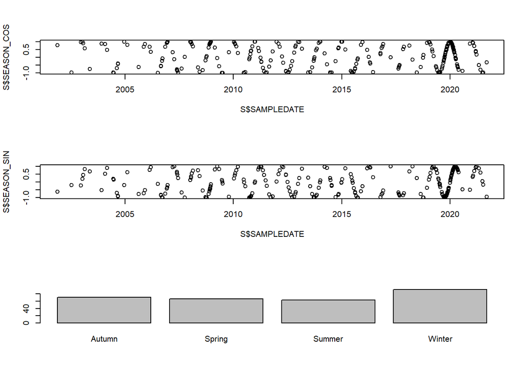

```r
# Add "CENTER_EMC","CENTER_LUMC", "CENTER_MSZ", "CENTER_OLVG", "CENTER_RAD", "CENTER_UMCU"
S <- S %>% mutate(CENTER_EMC = case_when(CENTER == "EMC" ~ 1,
                                                         CENTER != "EMC" ~ 0),
                                  CENTER_LUMC = case_when(CENTER == "LUMC" ~ 1,
                                                         CENTER != "LUMC" ~ 0),
                                  CENTER_MSZ = case_when(CENTER == "MSZ" ~ 1,
                                                         CENTER != "MSZ" ~ 0),
                                  CENTER_OLVG = case_when(CENTER == "OLVG" ~ 1,
                                                         CENTER != "OLVG" ~ 0),
                                  CENTER_RAD = case_when(CENTER == "RAD" ~ 1,
                                                         CENTER != "RAD" ~ 0),
                                  CENTER_UMCU = case_when(CENTER == "UMCU" ~ 1,
                                                         CENTER != "UMCU" ~ 0))
S <- S %>% mutate_at(c("CENTER_EMC","CENTER_LUMC","CENTER_MSZ",
                                       "CENTER_OLVG","CENTER_RAD","CENTER_UMCU"), as.factor)

# EC vs VCpersistent vs VCtransient, T1 vs T2
S <- S %>% mutate(ECVC = case_when(NONVIREMIC == 1 & LOSS == 0 ~ "EC", # only the persistent EC, i.e. VL <10,000 c/mL
                                   NONVIREMIC == 0 & LOSS == 0 ~ "VCpersistent",
                                   NONVIREMIC == 0 & LOSS == 1 ~ "VCtransient"),
                  ARTGROUP = case_when(ART == 1 & Timepoint == "T1" ~ "preART",
                                  ART == 1 & Timepoint == "T2" ~ "onART",
                                  ART == 0 & Timepoint == "T1" ~ "ARTnaiveT1",
                                  ART == 0 & Timepoint == "T2" ~ "ARTnaiveT2"))
S$GROUP3 <- paste(S$ECVC, S$ARTGROUP,sep = "_")
S$GROUP3 <- factor(S$GROUP3, levels=c("EC_ARTnaiveT1","EC_ARTnaiveT2",
                                      "EC_preART","EC_onART",
                                      "VCpersistent_ARTnaiveT1","VCpersistent_ARTnaiveT2",
                                      "VCpersistent_preART","VCpersistent_onART",
                                      "VCtransient_preART","VCtransient_onART"))
# There are 2 NAs, VC that start ART but their LOSS status is unknown.

# Seasonality sin & cos
## Calculate days since Jan2019
S$Days_since_Jan2001 <- as.numeric(S$SAMPLEDATE - as.Date("2001-01-01"))
S$SEASON_SIN <- sin((2*pi*S$Days_since_Jan2001)/365.2425)
S$SEASON_COS <- cos((2*pi*S$Days_since_Jan2001)/365.2425)

## for PCA, also determine actual season
S  %<>%
  # Extract inclusion month (in numbers)
  mutate(inclusion_month = as.numeric(stringr::str_split_i(.$SAMPLEDATE, '-', 2))) %>%
  # If individual is included in December, January or February: winter
  mutate(SEASON_CAT = as.factor(ifelse(.$inclusion_month %in% c(12, 1, 2), 'Winter',
                                  # if included in March, April or Mai: Spring
                                  ifelse(.$inclusion_month %in% c(3, 4, 5), 'Spring',
                                         # If included in June, July or August: Summer
                                         ifelse(.$inclusion_month %in% c(6, 7, 8), 'Summer',
                                                # If included in September, October or November: Autumn
                                                ifelse(.$inclusion_month %in% c(9, 10, 11), 'Autumn', NA))))))
## plot the season variables
par(mfrow = c(3,1))
plot(S$SEASON_COS~S$SAMPLEDATE)
plot(S$SEASON_SIN~S$SAMPLEDATE)
plot(S$SEASON_CAT)
```

```r
# Make sure the GROUP3 variable is last
S <- S[,c(1:(which(colnames(S)=="GROUP3")-1),
          (which(colnames(S)=="GROUP3")+1):ncol(S),
          which(colnames(S)=="GROUP3"))]

# Make a wide format again, for comparison of clinical values between timepoints
Swide <- S[,-which(colnames(S)=="GROUP3")] %>% pivot_wider(names_from = "Timepoint",
                           values_from = c("AGE","BMI","SMOKING_CURRENT","ARTGROUP","SampleID","SAMPLEDATE",
                                           "SEASON_CAT","SEASON_SIN","SEASON_COS","Days_since_Jan2001","inclusion_month","STORAGE_TIME"))
```

#### 2.2.0.1 Export the cleaned dataset for Time & ART, together with the olink data and info on ART types

```r
merge_df <- left_join(S, olink,by = "SampleID")

# Read additional ART data
artinfo <- openxlsx::read.xlsx(paste0(working_dir,"Inputs/Olink_SHM_ECVC_preART_vs_postART_206samp_2420Prots_masterdata.xlsx"))
artinfo <- artinfo[,c("COMP_1_ID",
           "T2_ART_DUR_DAYS",
           "T2_INSTI", "T2_NNRTI", "T2_PI")]
artinfo <- artinfo[grep("T2",artinfo$COMP_1_ID),] # only the T2 samples contain the ART info
colnames(artinfo)[1] <- "SampleID"

# join with main dataset
dfart <- left_join(merge_df, artinfo, by = "SampleID")

saveRDS(dfart, paste0(working_dir, "Outputs/AthenaOlink_Time_ART_Paired_Cleaned.rds"))
```

### 2.2.1 Summary of time difference for groups

```r
# what is the time window between T1 and T2? For each GROUP type
Swide$TIMEDIFF_YRS <- as.numeric(Swide$SAMPLEDATE_T2 - Swide$SAMPLEDATE_T1)/365.25

timepassed <- data.frame(EC_ARTnaive = 19, EC_onART = 9, VCpersistent_ARTnaive = 23, VCpersistent_onART = 57, VCtransient_onART = 36, row.names = "N")

{EC_ARTnaive <- summary(Swide$TIMEDIFF_YRS[which(Swide$ARTGROUP_T2 == "ARTnaiveT2" & Swide$ECVC == "EC")])
EC_onART <- summary(Swide$TIMEDIFF_YRS[which(Swide$ARTGROUP_T2 == "onART" & Swide$ECVC == "EC")])
VCpersistent_ARTnaive <- summary(Swide$TIMEDIFF_YRS[which(Swide$ARTGROUP_T2 == "ARTnaiveT2" & Swide$ECVC == "VCpersistent")])
VCpersistent_onART <- summary(Swide$TIMEDIFF_YRS[which(Swide$ARTGROUP_T2 == "onART" & Swide$ECVC == "VCpersistent")])
VCtransient_onART <- summary(Swide$TIMEDIFF_YRS[which(Swide$ARTGROUP_T2 == "onART" & Swide$ECVC == "VCtransient")])}

timepassed["Time difference (years)",] <-
  c(paste0(round(EC_ARTnaive[3],1),
          " (",round(EC_ARTnaive[2],1),
          " - ",round(EC_ARTnaive[5],1),
          ")"),
    paste0(round(EC_onART[3],1),
          " (",round(EC_onART[2],1),
          " - ",round(EC_onART[5],1),
          ")"),
    paste0(round(VCpersistent_ARTnaive[3],1),
          " (",round(VCpersistent_ARTnaive[2],1),
          " - ",round(VCpersistent_ARTnaive[5],1),
          ")"),
    paste0(round(VCpersistent_onART[3],1),
          " (",round(VCpersistent_onART[2],1),
          " - ",round(VCpersistent_onART[5],1),
          ")"),
    paste0(round(VCtransient_onART[3],1),
          " (",round(VCtransient_onART[2],1),
          " - ",round(VCtransient_onART[5],1),
          ")"))

# How long are the EC and VC on ART?
Swide$TIMEART_YRS <- as.numeric(Swide$SAMPLEDATE_T2 - Swide$ART_START)/365.25
summary(Swide$TIMEART_YRS)
```

```
##     Min.  1st Qu.   Median     Mean  3rd Qu.     Max.     NA's
##  0.05476  3.07324  5.30322  5.48309  7.77276 12.95825      186
```

```r
{EC_ARTnaive <- summary(Swide$TIMEART_YRS[which(Swide$ARTGROUP_T2 == "ARTnaiveT2" & Swide$ECVC == "EC")])
EC_onART <- summary(Swide$TIMEART_YRS[which(Swide$ARTGROUP_T2 == "onART" & Swide$ECVC == "EC")])
VC_ARTnaive <- summary(Swide$TIMEART_YRS[which(Swide$ARTGROUP_T2 == "ARTnaiveT2" & Swide$ECVC == "VC")])
VCpersistent_onART <- summary(Swide$TIMEART_YRS[which(Swide$ARTGROUP_T2 == "onART" & Swide$ECVC == "VCpersistent")])
VCtransient_onART <- summary(Swide$TIMEART_YRS[which(Swide$ARTGROUP_T2 == "onART" & Swide$ECVC == "VCtransient")])
}

timepassed["Time on ART (years)",] <-
  c(paste0(round(EC_ARTnaive[3],1),
          " (",round(EC_ARTnaive[2],1),
          " - ",round(EC_ARTnaive[5],1),
          ")"),
    paste0(round(EC_onART[3],1),
          " (",round(EC_onART[2],1),
          " - ",round(EC_onART[5],1),
          ")"),
    paste0(round(VC_ARTnaive[3],1),
          " (",round(VC_ARTnaive[2],1),
          " - ",round(VC_ARTnaive[5],1),
          ")"),
    paste0(round(VCpersistent_onART[3],1),
          " (",round(VCpersistent_onART[2],1),
          " - ",round(VCpersistent_onART[5],1),
          ")"),
    paste0(round(VCtransient_onART[3],1),
          " (",round(VCtransient_onART[2],1),
          " - ",round(VCtransient_onART[5],1),
          ")"))
timepassed
```

```
##                             EC_ARTnaive        EC_onART VCpersistent_ARTnaive
## N                                    19               9                    23
## Time difference (years) 4.2 (4.2 - 4.2)    NA (NA - NA)          NA (NA - NA)
## Time on ART (years)        NA (NA - NA) 3.1 (2.5 - 5.2)          NA (NA - NA)
##                         VCpersistent_onART VCtransient_onART
## N                                       57                36
## Time difference (years)       NA (NA - NA)      NA (NA - NA)
## Time on ART (years)        5.3 (3.1 - 8.1)     5.4 (3.9 - 8)
```

```r
openxlsx::write.xlsx(cbind(rownames(timepassed),timepassed),paste0(working_dir, "Outputs/Supplements_ECVCART_timediff.xlsx"),asTable = T)
```

### 2.2.2 Evaluate clinical characteristics between groups

Remove the single patient with unknown LOSS, i.e. VL exactly 10,000 at T2 sample.

```r
S <- S[-which(is.na(S$GROUP3)),]
```

[figure not shown]

```r
ggsave(paste0(working_dir, "Outputs/Supplements_ECVCART_Demographics_between_groups1.pdf"),
       suppressWarnings(gridExtra::grid.arrange(

# continuous variables

  ggplot(S,aes(x=GROUP3, y=AGE)) +
    geom_jitter(shape=16, position=position_jitter(0.2),size = .1) +
    geom_boxplot(width = .5,outlier.shape = NA) +
    theme_bw() + theme(axis.text.x = element_text(colour="black", angle=45, hjust =1)) + xlab("") +
    ggtitle("AGE",subtitle = paste("Kruskal-Wallis P =",signif(kruskal.test(S$AGE~S$GROUP3)$p.value,3))),

  ggplot(S,aes(x=GROUP3, y=SEASON_SIN)) +
    geom_jitter(shape=16, position=position_jitter(0.2),size = .1) +
    geom_boxplot(width = .5,outlier.shape = NA) +
    theme_bw() + theme(axis.text.x = element_text(colour="black", angle=45, hjust =1)) + xlab("") +
    ggtitle("SEASON_SIN",subtitle = paste("Kruskal-Wallis P =",signif(kruskal.test(S$SEASON_SIN~S$GROUP3)$p.value,3))),

  ggplot(S,aes(x=GROUP3, y=SEASON_COS)) +
    geom_jitter(shape=16, position=position_jitter(0.2),size = .1) +
    geom_boxplot(width = .5,outlier.shape = NA) +
    theme_bw() + theme(axis.text.x = element_text(colour="black", angle=45, hjust =1)) + xlab("") +
    ggtitle("SEASON_COS",subtitle = paste("Kruskal-Wallis P =",signif(kruskal.test(S$SEASON_COS~S$GROUP3)$p.value,3))),

  ggplot(S,aes(x=GROUP3, y=BMI)) +
    geom_jitter(shape=16, position=position_jitter(0.2),size = .1) +
    geom_boxplot(width = .5,outlier.shape = NA) +
    theme_bw() + theme(axis.text.x = element_text(colour="black", angle=45, hjust =1)) + xlab("") +
    ggtitle("BMI",subtitle = paste("Kruskal-Wallis P =",signif(kruskal.test(S$BMI~S$GROUP3)$p.value,3))),

  ggplot(S,aes(x=GROUP3, y=STORAGE_TIME)) +
    geom_jitter(shape=16, position=position_jitter(0.2),size = .1) +
    geom_boxplot(width = .5,outlier.shape = NA) +
    theme_bw() + theme(axis.text.x = element_text(colour="black", angle=45, hjust =1)) + xlab("") +
    ggtitle("STORAGE_TIME",subtitle = paste("Kruskal-Wallis P =",signif(kruskal.test(S$STORAGE_TIME~S$GROUP3)$p.value,3))),

  ggplot(S,aes(x=GROUP3, y=VL)) +
    geom_jitter(shape=16, position=position_jitter(0.2),size = .1) +
    geom_boxplot(width = .5,outlier.shape = NA) +
    theme_bw() + theme(axis.text.x = element_text(colour="black", angle=45, hjust =1)) + xlab("") +
    ggtitle("VL",subtitle = paste("Kruskal-Wallis P =",signif(kruskal.test(S$VL~S$GROUP3)$p.value,3))),

  ggplot(S,aes(x=GROUP3, y=CD4)) +
    geom_jitter(shape=16, position=position_jitter(0.2),size = .1) +
    geom_boxplot(width = .5,outlier.shape = NA) +
    theme_bw() + theme(axis.text.x = element_text(colour="black", angle=45, hjust =1)) + xlab("") +
    ggtitle("CD4",subtitle = paste("Kruskal-Wallis P =",signif(kruskal.test(S$CD4~S$GROUP3)$p.value,3))),

# categorical variables

  ggplot(S, aes(GROUP3))+
    geom_bar(aes(fill=as.factor(SEX)), position="fill", width = 0.5, color = "black") +
    theme_bw() + labs(fill="") + theme(axis.text.x = element_text(angle=45, hjust=1))+
    ggtitle("SEX",subtitle = paste("Chi squared P =",signif(chisq.test(S$SEX,S$GROUP3)$p.value,3)))

,ncol = 2)),
       width = 210, height = 297, units = "mm") # A4 size
```

[figure not shown]

```r
# make a second page, it doesn't fit otherwise
ggsave(paste0(working_dir, "Outputs/Supplements_ECVCART_Demographics_between_groups2.pdf"),
       suppressWarnings(gridExtra::grid.arrange(
  ggplot(S, aes(GROUP3))+
    geom_bar(aes(fill=as.factor(CENTER)), position="fill", width = 0.5, color = "black") +
    theme_bw() + labs(fill="") + theme(axis.text.x = element_text(angle=45, hjust=1))+
    ggtitle("CENTER",subtitle = paste("Chi squared P =",signif(chisq.test(S$CENTER,S$GROUP3)$p.value,3))),

  ggplot(S, aes(GROUP3))+
    geom_bar(aes(fill=as.factor(SEASON_CAT)), position="fill", width = 0.5, color = "black") +
    theme_bw() + labs(fill="") + theme(axis.text.x = element_text(angle=45, hjust=1))+
    ggtitle("SEASON_CAT",subtitle = paste("Chi squared P =",signif(chisq.test(S$SEASON_CAT,S$GROUP3)$p.value,3))),

  ggplot(S, aes(GROUP3))+
    geom_bar(aes(fill=as.factor(ETHNICITY)), position="fill", width = 0.5, color = "black") +
    theme_bw() + labs(fill="") + theme(axis.text.x = element_text(angle=45, hjust=1))+
    ggtitle("ETHNICITY",subtitle = paste("Chi squared P =",signif(chisq.test(S$ETHNICITY,S$GROUP3)$p.value,3))),

  ggplot(S, aes(GROUP3))+
    geom_bar(aes(fill=as.factor(SMOKING_CURRENT)), position="fill", width = 0.5, color = "black") +
    theme_bw() + labs(fill="") + theme(axis.text.x = element_text(angle=45, hjust=1))+
    ggtitle("SMOKING_CURRENT",subtitle = paste("Chi squared P =",signif(chisq.test(S$SMOKING_CURRENT,S$GROUP3)$p.value,3))),

  ggplot(S, aes(GROUP3))+
    geom_bar(aes(fill=as.factor(SMOKING_NEVER)), position="fill", width = 0.5, color = "black") +
    theme_bw() + labs(fill="") + theme(axis.text.x = element_text(angle=45, hjust=1))+
    ggtitle("SMOKING_NEVER",subtitle = paste("Chi squared P =",signif(chisq.test(S$SMOKING_NEVER,S$GROUP3)$p.value,3)))

,ncol = 2)),
       width = 210, height = 297, units = "mm") # A4 size
```

#### Interpretation

- AGE is different between the samples
- SEASON_COS and SEASON_SIN are only slightly different between the samples, as is categorical season
- STORAGE_TIME is severly skewed between samples.
- BMI is similar
- SEX is similar between paired comparisons: only the EC who do not start ART are more often female, but between ART groups this is similar.
- CENTER is different between the paired comparisions: Expecially EMC and MSZ contribution varies
- ETHNICITY is slightly different between comparisons, mainly the proportion of white, black and unknown.
- SMOKING seems to minimally decrease in general; however, the number of NA varies more.

In summary: AGE, seasonality, STORAGE_TIME are very important to evaluate. CENTER, ETHNICITY and SEX are inherently stable within comparisons and could be evaluated as sensitivity, to see if the effect of time and ART is different between CENTER, ETHNICITIES or SEXES.

### 2.2.3 ADDENDUM 26-1-2025: what were the VL of the 9 EC_preART like at start ART?

```r
ECONLY_ART <- S %>%
  filter(GROUP3 == "EC_preART") %>%
  mutate(UNDETECTABLE_AT_ART = case_when(
    as.numeric(T1_VL) < 50 ~ "Undetectable at ART",
    as.numeric(T1_VL) >= 50 ~ "Detectable viremia 50-1000 copies/mL at ART",
    TRUE ~ NA_character_
  )) %>%
  mutate(UNDETECTABLE_AT_ART = as.factor(UNDETECTABLE_AT_ART)) %>%
  select(matches("ID|SampleID|UNDETECTABLE_AT_ART|VL")) %>%
  droplevels()

summary(ECONLY_ART$UNDETECTABLE_AT_ART)
```

```
## Detectable viremia 50-1000 copies/mL at ART
##                                           4
##                         Undetectable at ART
##                                           5
```

```r
temp <- ECONLY_ART %>%
  mutate(SampleID = str_replace(SampleID, "_T1$", "_T2"))

ECONLY_ART <- ECONLY_ART %>%
  bind_rows(temp) %>%
  left_join(olink, by = "SampleID") %>%
  mutate(Time = stringr::str_split_i(SampleID, "_", 2)) %>%
  select(ID, SampleID, Time, UNDETECTABLE_AT_ART, LY9, CD6, CRTAM, VAT1)
```

Boxplots stratisfied by Undetectable at ART for the 4 markers.

```r
# ECONLY_ART
# pivot longer again for ggplot facet grid/wrap
ECONLY_ARTlong <- ECONLY_ART %>%
  pivot_longer(
    cols = c(LY9, CD6, CRTAM, VAT1),
    names_to = "Protein",
    values_to = "Value",
  ) %>%
  select(ID, Time, UNDETECTABLE_AT_ART, Protein, Value)

g <- ggplot(ECONLY_ARTlong, aes(x = Time, y = Value, fill = UNDETECTABLE_AT_ART))+
  geom_violin(alpha=0.3, position = position_dodge(width = .9), linewidth=.1, color=NA) +
  ggtitle("Delta NPX")+
  geom_boxplot(notch = FALSE,  outlier.size = -1, width=.15,
               #color="black",
               lwd=.5, position = position_dodge(width = .9),
               alpha = 0.5,show.legend = F)+
  geom_jitter( shape= 21, size=.5,
               position = position_dodge2(width = 0.75),
               aes(color = UNDETECTABLE_AT_ART),alpha=.5)+
  ylab(c("Delta Log2 NPX"))  +
  xlab(c(""))  +
  facet_grid(Protein~UNDETECTABLE_AT_ART, scales = "free")+#
  theme_bw(base_size = 8)+
  guides(fill = guide_legend(override.aes = list(alpha = .5,color="black")))+
  scale_fill_manual(values=c("blue4", "darkgrey"))+
  scale_color_manual(values=c("blue4", "darkgrey"))+
  theme(legend.position = "none",
    axis.text.x = element_blank(),
    axis.text.y = element_text(color=  "black"),
    axis.ticks.x = element_blank())

ggsave(paste0(working_dir, "Outputs/Supplements_Figure_PAIRED_EConlyART_CRTAMLY9CD6VAT1.pdf"),g, dpi = 300,width = 210/2, height = 297/2, units = "mm" )

g <- g + geom_line(linewidth =  0.5, color = "black", aes(group = ID), alpha = 0.3, position = position_dodge(width = 0.75))

ggsave(paste0(working_dir, "Outputs/Supplements_Figure_PAIRED_WITHLINES_EConlyART_CRTAMLY9CD6VAT1.pdf"),g, dpi = 300,width = 210/2, height = 297/2, units = "mm" )

# Paired T test, split by ECONLY_ARTWIDE
# pivot wider
ECONLY_ARTwide <- ECONLY_ART %>%
  mutate(TIME = stringr::str_split_i(SampleID, "_", 2)) %>%
  pivot_wider(
    id_cols = c(ID, UNDETECTABLE_AT_ART),
    names_from = TIME,
    values_from = c(LY9, CD6, CRTAM, VAT1)
  )
# calculate delta npx
ECONLY_ARTwide <- ECONLY_ARTwide %>%
  mutate(
    LY9_deltaNPX = abs(LY9_T1 - LY9_T2),
    CD6_deltaNPX = abs(CD6_T1 - CD6_T2),
    CRTAM_deltaNPX = abs(CRTAM_T1 - CRTAM_T2),
    VAT1_deltaNPX = abs(VAT1_T1 - VAT1_T2)
  )

vldetect <- ECONLY_ARTwide %>% filter(UNDETECTABLE_AT_ART == "Detectable viremia 50-1000 copies/mL at ART")

vlundetect <- ECONLY_ARTwide %>% filter(UNDETECTABLE_AT_ART == "Undetectable at ART")

printpvalues_paired <- function(df){
  for (protein_colname in c("LY9", "CD6", "CRTAM", "VAT1")){
    df <- data.frame(df)
    print(protein_colname)
    T1name <- paste0(protein_colname, "_T1")
    T2name <- paste0(protein_colname, "_T2")
    pvalue <- signif(t.test(df[,T1name] , df[,T2name], paired = TRUE)$p.value,3)
    print(paste0("P = ", pvalue))
    print('')
  }
}

printpvalues_paired(vldetect)
```

```
## [1] "LY9"
## [1] "P = 0.178"
## [1] ""
## [1] "CD6"
## [1] "P = 0.189"
## [1] ""
## [1] "CRTAM"
## [1] "P = 0.0997"
## [1] ""
## [1] "VAT1"
## [1] "P = 0.355"
## [1] ""
```

```r
printpvalues_paired(vlundetect)
```

```
## [1] "LY9"
## [1] "P = 0.0223"
## [1] ""
## [1] "CD6"
## [1] "P = 0.0413"
## [1] ""
## [1] "CRTAM"
## [1] "P = 0.123"
## [1] ""
## [1] "VAT1"
## [1] "P = 0.978"
## [1] ""
```

```r
df <- data.frame(ECONLY_ARTwide)
# t.test(df[,"LY9_T1"], df[,"LY9_T2"], paired = TRUE)

newdf <- ECONLY_ARTlong %>% mutate(Time = case_when(Time == "T1" ~ "Before ART",
                                                    Time == "T2" ~ "After ART"))

# Boxplot for all 9 EC before and after
g <- ggplot(newdf, aes(x = Time, y = Value, fill = "black"))+
  geom_violin(alpha=0.3, position = position_dodge(width = .9), linewidth=.1, color=NA) +
  ggtitle("Change in Normalized Protein Expression (NPX) in N = 9 EC before and after ART")+
  geom_boxplot(notch = FALSE,  outlier.size = -1, width=.15,
               #color="black",
               lwd=.5, position = position_dodge(width = .9),
               alpha = 0.5,show.legend = F)+
  geom_jitter( shape= 21, size=.5,
               position = position_dodge2(width = 0.75),
               aes(color = "black"),alpha=.5)+
  ylab(c("Log2 NPX"))  +
  xlab(c(""))  +
  facet_grid(.~Protein, scales = "free")+#
  theme_bw(base_size = 8)+
  guides(fill = guide_legend(override.aes = list(alpha = .5,color="black")))+
  scale_fill_manual(values=c("yellow3", "darkgrey"))+
  scale_color_manual(values=c("yellow3", "darkgrey"))+
  theme(legend.position = "none",
    axis.text.x = element_text(color=  "black", size = 8),
    axis.text.y = element_text(color=  "black", size = 8),
    axis.ticks.x = element_blank())

ggsave(paste0(working_dir, "Outputs/Supplements_Figure_PAIRED_EConlyART_CRTAMLY9CD6VAT1_Unstratified.pdf"),g, dpi = 300,width = 210/1, height = 297/4, units = "mm" )

g <- g + geom_line(linewidth =  0.5, color = "black", aes(group = ID), alpha = 0.3, position = position_dodge(width = 0.75))

ggsave(paste0(working_dir, "Outputs/Supplements_Figure_PAIRED_WITHLINES_EConlyART_CRTAMLY9CD6VAT1_Unstratified.pdf"),g, dpi = 300,width = 210/1, height = 297/4, units = "mm" )
```

Also do delta NPX. And t-test because of small sample size.

```r
# pivot longer again for ggplot facet grid/wrap
ECONLY_ARTdeltaNPX <- ECONLY_ARTwide %>%
  pivot_longer(
    cols = c(LY9_deltaNPX, CD6_deltaNPX, CRTAM_deltaNPX, VAT1_deltaNPX),
    names_to = "Protein",
    values_to = "deltaNPX"
  ) %>%
  select(ID, UNDETECTABLE_AT_ART, Protein, deltaNPX)

# boxplot delta npx between the two groups
g <- ggplot(ECONLY_ARTdeltaNPX, aes(x = UNDETECTABLE_AT_ART, y = deltaNPX, fill = UNDETECTABLE_AT_ART))+
  geom_violin(alpha=0.3, position = position_dodge(width = .9), linewidth=.1, color=NA) +
  ggtitle("Delta NPX")+
  geom_boxplot(notch = FALSE,  outlier.size = -1, width=.15,
               #color="black",
               lwd=.5, position = position_dodge(width = .9),
               alpha = 0.5,show.legend = F)+
  geom_jitter( shape= 21, size=.5,
               position = position_dodge2(width = 0.75),
               aes(color = UNDETECTABLE_AT_ART),alpha=.5)+
  ylab(c("Delta Log2 NPX"))  +
  xlab(c(""))  +
  facet_wrap(~Protein, scales = "free",ncol = 2)+#
  theme_bw(base_size = 8)+
  guides(fill = guide_legend(override.aes = list(alpha = .5,color="black")))+
  scale_fill_manual(values=c("blue4", "darkgrey"))+
  scale_color_manual(values=c("blue4", "darkgrey"))+
  theme(legend.position = "none",
    axis.text.x = element_blank(),
    axis.text.y = element_text(color=  "black"),
    axis.ticks.x = element_blank())

ggsave(paste0(working_dir, "Outputs/Supplements_Figure_DeltaNPX_EConlyART_CRTAMLY9CD6VAT1.pdf"),g, dpi = 300,width = 210/2, height = 297/4, units = "mm" )

# statistical testing
df <- data.frame(ECONLY_ARTwide)
for (protein_colname in c("LY9_deltaNPX", "CD6_deltaNPX", "CRTAM_deltaNPX", "VAT1_deltaNPX")){
  print(stringr::str_split_i(protein_colname,"_",1))
  print(paste0("P = ",signif(t.test(df[,protein_colname]~df$UNDETECTABLE_AT_ART)$p.value,3)))
  print('')
}
```

```
## [1] "LY9"
## [1] "P = 0.364"
## [1] ""
## [1] "CD6"
## [1] "P = 0.356"
## [1] ""
## [1] "CRTAM"
## [1] "P = 0.277"
## [1] ""
## [1] "VAT1"
## [1] "P = 0.92"
## [1] ""
```

#### 2.2.3.1 Extra check: ART regimens for EC only

```r
# Read additional ART data
artinfo <- readxl::read_xlsx(paste0(working_dir, "Inputs/Olink_SHM_ECVC_preART_vs_postART_206samp_2420Prots_masterdata.xlsx")) %>%
  select(COMP_1_ID, T2_ART_DUR_DAYS, T2_INSTI, T2_NNRTI, T2_PI) %>%
  filter(str_detect(COMP_1_ID, "T2")) %>%
  rename(SampleID = COMP_1_ID)

# Join with other dataset
artinfo <- ECONLY_ART %>% filter(str_detect(SampleID, "_T2$")) %>%
  left_join(artinfo, by = "SampleID")

# Create tables
c("T2_ART_DUR_DAYS", "T2_INSTI", "T2_NNRTI", "T2_PI") %>%
  map(~table(artinfo[[.x]], artinfo$UNDETECTABLE_AT_ART))
```

```
## [[1]]
##
##        Detectable viremia 50-1000 copies/mL at ART Undetectable at ART
##   46                                             0                   1
##   622                                            0                   1
##   930                                            0                   1
##   1011                                           1                   0
##   1120                                           0                   1
##   1839                                           1                   0
##   1912                                           1                   0
##   2077                                           0                   1
##   2479                                           1                   0
##
## [[2]]
##
##     Detectable viremia 50-1000 copies/mL at ART Undetectable at ART
##   0                                           2                   1
##   1                                           2                   4
##
## [[3]]
##
##     Detectable viremia 50-1000 copies/mL at ART Undetectable at ART
##   0                                           2                   5
##   1                                           2                   0
##
## [[4]]
##
##     Detectable viremia 50-1000 copies/mL at ART Undetectable at ART
##   0                                           4                   4
##   1                                           0                   1
```

# 3 Cleaning longitudinal data: survival models loss of control status

### 3.0.1 Read and clean the data

*Note: FU stands for follow-up*

In the dataset, the following variables and their meanings are: * T1_DATE is start of follow-up * EVENT_DATE is LOSS_DATE # I checked: this is always before ART_START * LOSS_DATE is the first date that VL reaches >10,000 c/mL * LATEST_DATE is the last available entry in the SHM dataset * FU_TOTAL is the time in years betweeen HIV diagnosis and LATEST_DATE * FU_END is the minimum of LOSS_DATE, ART_START and LATEST_DATE with `na.rm=T` * HIV_DATE can be derived from HIV_DUR_T1 and T1_DATE

For survival analyses,: * T1_DATE is start of follow-up * FU_END is the time in days end of follow-up, censored at ART_START or end of follow-up where applicable * FU_END_DATE can be derived by adding FU_END to T1_DATE. * STATUS is event yes/no, which can be derived from LOSS, a factor with two levels: Kept_EC_status and Lost_EC_status * CENSORED can be derived from LOSS == Kept_EC_status & ART == 1

```r
# read data
df <- openxlsx::read.xlsx(paste0(working_dir, "Inputs/Olink_SHM_ECVC_Loss_vs_NoLoss_181samp_2420Prots_masterdata.xlsx"))
colnames(df)[1] <- "SampleID"

# 3 individuals with the note "no 6 months ART", set to NA
df[which(df$ART_START == "no 6 months ART"),"ART_START"] <- NA

# Prepare dataset
df <- df %>%
  # Define STATUS (event yes/no where 1 == event happened and 0 == no event)
  mutate(STATUS = case_when(LOSS == "Kept_EC_status"~ 0,
                            LOSS == "Lost_EC_status"~ 1)) %>%
  # Define END_DATE which is FU_END plus T1_DATE
  mutate(FU_END_DATE = FU_END + T1_DATE) %>%
  # CENSORED if ART is started without Loss. Note that Loss always comes before ART in this dataset.
  mutate(CENSORED_ART = case_when(LOSS == "Kept_EC_status" & ART == 1 ~ 1,
                              LOSS == "Lost_EC_status" | ART == 0 ~ 0)) %>%
  # define HIV_DATE with HIV_DUR_T1 and T1_DATE. Note that HIV_DUR_T1 is in years
  mutate(HIV_D = T1_DATE - (HIV_DUR_T1*365.25)) %>%
  # rename age and storage time colnames,
  dplyr::rename(AGE = AGE_T1, STORAGE_TIME = Storage_time) %>%
  # define ethnicity_white and ethnicity_black
  mutate(ETHNICITY_WHITE = case_when(ETHNICITY == "White" ~ 1,
                                     ETHNICITY != "White" & !is.na(ETHNICITY) ~ 0),
         ETHNICITY_BLACK = case_when(ETHNICITY == "Black" ~ 1,
                                     ETHNICITY != "Black" & !is.na(ETHNICITY) ~ 0)) %>%
  # CENTER dummy variables
  mutate(CENTER_EMC = case_when(CENTER == "EMC" ~ 1, CENTER != "EMC" ~ 0),
          CENTER_LUMC = case_when(CENTER == "LUMC" ~ 1, CENTER != "LUMC" ~ 0),
          CENTER_MSZ = case_when(CENTER == "MSZ" ~ 1, CENTER != "MSZ" ~ 0),
          CENTER_OLVG = case_when(CENTER == "OLVG" ~ 1, CENTER != "OLVG" ~ 0),
          CENTER_RAD = case_when(CENTER == "RAD" ~ 1, CENTER != "RAD" ~ 0),
          CENTER_UMCU = case_when(CENTER == "UMCU" ~ 1, CENTER != "UMCU" ~ 0)) %>%
  # transform factors
  mutate_at(c("CENTER", "COHORT", "SEX", "NONVIREMIC", "ETHNICITY", "ETHNICITY_WHITE",
               "ETHNICITY_BLACK","SMOKING_CURRENT_T1", "SMOKING_EVER_T1",
               "ART", "LOSS", "CENTER_EMC","CENTER_LUMC","CENTER_MSZ",
               "CENTER_OLVG","CENTER_RAD","CENTER_UMCU"), as.factor) %>%
  # transform dates
  mutate_at(c("T1_DATE","ART_START","LOSS_DATE","LATEST_DATE","FU_END_DATE","HIV_D"),
                   openxlsx::convertToDate)

  # select variables
colnames_olink = colnames(df)[c(grep("GP2", colnames(df)): grep("NFU1", colnames(df)))]
columns_to_select <- c(
  "SampleID", "T1_DATE", "T1_VL", "HIV_D",
  "ART", "ART_START", "LOSS", "LOSS_DATE", "LATEST_DATE", "NONVIREMIC",
  "FU_TOTAL", "FU_END", "FU_END_DATE", "CENSORED_ART", "STATUS",
  "AGE", "SEX", "CENTER", "CENTER_EMC", "CENTER_LUMC", "CENTER_MSZ",
  "CENTER_OLVG", "CENTER_RAD", "CENTER_UMCU",
  "STORAGE_TIME", "ETHNICITY", "ETHNICITY_WHITE", "ETHNICITY_BLACK",
  colnames_olink
)

df <- df[, columns_to_select]

table(df$LOSS, df$NONVIREMIC)
```

```
##
##                   0  1
##   Kept_EC_status 90 35
##   Lost_EC_status 55  1
```

```r
table(df$LOSS, df$CENSORED_ART)
```

```
##
##                   0  1
##   Kept_EC_status 44 81
##   Lost_EC_status 56  0
```

```r
# Read VL data
dynamic_vl <- openxlsx::read.xlsx(paste0(working_dir, "Inputs/20230729_ALL_CD4_VL_eliteATHENA.xlsx"),sheet=3) %>%
  dplyr::mutate(RNA_D = openxlsx::convertToDate(RNA_D),
                YEAR_FU = lubridate::year(RNA_D), # taking the year reduces resolution
                RNA_c= ifelse(RNA_UDT==1 | RNA<50,50,RNA)) #change undetected RNA per center to 50 (Lower detection limit) #anything below 50 to 50 (Lower detection limit) 4551 observations
colnames(dynamic_vl)[1] <- "SampleID"

head(dynamic_vl)
```

```
##      SampleID          PID      RNA_D RNA_UDT  RNA YEAR_FU RNA_c
## 1 EL-00220_T1 SHM-EL-00220 2007-09-24       0  800    2007   800
## 2 EL-00220_T1 SHM-EL-00220 2007-10-22       0 2000    2007  2000
## 3 EL-00220_T1 SHM-EL-00220 2008-03-10       0 1000    2008  1000
## 4 EL-00220_T1 SHM-EL-00220 2008-07-14       0  700    2008   700
## 5 EL-00220_T1 SHM-EL-00220 2008-11-27       0  700    2008   700
## 6 EL-00220_T1 SHM-EL-00220 2009-07-10       0 2000    2009  2000
```

```r
# Join LOSS, NONVIREMIC, T1_DATE, FU_END_DATE
dynamic_vl <- left_join(dynamic_vl, df[,c("SampleID","LOSS","LOSS_DATE", "NONVIREMIC", "T1_DATE", "T1_VL", "FU_END_DATE", "HIV_D")], by = "SampleID")

# remove the measurements from IDs that are not in the final dataset
dynamic_vl <- dynamic_vl[-which(is.na(dynamic_vl$LOSS)),]

# VL measurements must be from on or before FU_END_DATE, which is loss, ART or end of follow-up
dynamic_vl <- dynamic_vl[which(dynamic_vl$RNA_D <= dynamic_vl$FU_END_DATE),]

# add time in years since first measurement
dynamic_vl <- dynamic_vl %>% group_by(SampleID) %>%
  mutate(OLDEST = min(RNA_D)) %>%
  mutate(YEARS_SINCE_T0 = as.numeric((RNA_D - OLDEST)/365.25)) %>%
  mutate(YEARS_SINCE_HIV = as.numeric((RNA_D - HIV_D)/365.25))

dynamic_vl$YEARS_SINCE_T0_ROUNDED <- round(dynamic_vl$YEARS_SINCE_T0,0)
```

Note that for N=2 individuals we do not have longitudinal VL data available.

#### 3.0.1.1 Export the dataframe

```r
saveRDS(df, paste0(working_dir, "Outputs/AthenaOlink_Loss_vs_NoLoss_Cleaned.rds"))

saveRDS(dynamic_vl, paste0(working_dir, "Outputs/AthenaOlink_Longitudinal_ViralLoad_Cleaned.rds"))
```

## 3.1 Add CD4 dynamics

### 3.1.1 Read and clean CD4 data

```r
# Read CD4 data
dynamic_cd4 <- openxlsx::read.xlsx(paste0(working_dir, "Inputs/20230729_ALL_CD4_VL_eliteATHENA.xlsx"),sheet=2) %>%
  dplyr::mutate(CD4_D = openxlsx::convertToDate(CD4_D))
colnames(dynamic_cd4)[1] <- "SampleID"

# Join LOSS, NONVIREMIC, T1_DATE, FU_END_DATE
dynamic_cd4 <- left_join(dynamic_cd4, df[,c("SampleID","LOSS","LOSS_DATE", "NONVIREMIC", "T1_DATE", "T1_VL", "FU_END_DATE", "HIV_D")], by = "SampleID")
# Also join T1_CD4
addt1cd4 <- openxlsx::read.xlsx(paste0(working_dir, "Inputs/Olink_SHM_ECVC_Loss_vs_NoLoss_181samp_2420Prots_masterdata.xlsx"))
colnames(addt1cd4)[1] <- "SampleID"
dynamic_cd4 <- left_join(dynamic_cd4,addt1cd4[,c("SampleID", "T1_CD4")], by = "SampleID")

# remove the measurements from IDs that are not in the final dataset
dynamic_cd4 <- dynamic_cd4[-which(is.na(dynamic_cd4$LOSS)),]

# VL measurements must be from on or before FU_END_DATE, which is loss, ART or end of follow-up
dynamic_cd4 <- dynamic_cd4[which(dynamic_cd4$CD4_D <= dynamic_cd4$FU_END_DATE),]

# add time in years since first measurement
dynamic_cd4 <- dynamic_cd4 %>% group_by(SampleID) %>%
  mutate(OLDEST = min(CD4_D)) %>%
  mutate(YEARS_SINCE_T0 = as.numeric((CD4_D - OLDEST)/365.25),
         YEARS_SINCE_T1 = as.numeric((CD4_D - T1_DATE)/365.25),
         YEARS_SINCE_HIV = as.numeric((CD4_D - HIV_D)/365.25))

length(unique(dynamic_cd4$SampleID))
```

```
## [1] 179
```

```r
# make sure dates are in ascending order for moving median
dynamic_cd4 <- dynamic_cd4 %>% arrange(SampleID, CD4_D)

# test moving median out with one patient
test <- dynamic_cd4 %>% filter(PID == dynamic_cd4$PID[100])
test <- test[,c(1:5,12)]
library(slider)
test$rollingmean <- slide_mean(test$CD4A,before = 2, after = 2,na_rm = T)
test$rollingmean_index <- slide_index_mean(x = test$CD4A, i = test$CD4_D, before = 365, after = 365, na_rm = T)
test$rollingmedian_index <- slide_index_dbl(.x = test$CD4A, .i = test$CD4_D, .f = median, .before = 365, .after = 365)
test[,c(3:8)]
```

```
## # A tibble: 19 × 6
##    CD4_D       CD4A LOSS           T1_CD4 rollingmean rollingmean_index
##    <date>     <dbl> <fct>           <dbl>       <dbl>             <dbl>
##  1 2013-03-18   460 Kept_EC_status    680        637.              635
##  2 2013-06-24   650 Kept_EC_status    680        635               630
##  3 2013-10-28   800 Kept_EC_status    680        630               630
##  4 2014-03-03   630 Kept_EC_status    680        672               637.
##  5 2014-06-17   610 Kept_EC_status    680        678               673.
##  6 2014-12-03   670 Kept_EC_status    680        668               648.
##  7 2015-06-03   680 Kept_EC_status    680        690               678.
##  8 2016-02-16   750 Kept_EC_status    680        710               723.
##  9 2016-12-21   740 Kept_EC_status    680        740               733.
## 10 2017-11-06   710 Kept_EC_status    680        842               865
## 11 2018-05-03   820 Kept_EC_status    680        860               882
## 12 2018-09-04  1190 Kept_EC_status    680        882               857.
## 13 2018-11-13   840 Kept_EC_status    680        886               886
## 14 2019-02-27   850 Kept_EC_status    680        932               913.
## 15 2019-08-28   730 Kept_EC_status    680        846               903.
## 16 2020-01-07  1050 Kept_EC_status    680        880               848.
## 17 2020-07-08   760 Kept_EC_status    680        966               847.
## 18 2021-08-18  1010 Kept_EC_status    680       1025              1145
## 19 2022-04-19  1280 Kept_EC_status    680       1017.             1145
```

```r
# add a moving median with index window -365 to +365 days.
dynamic_cd4 <- dynamic_cd4 %>% group_by(SampleID) %>% mutate(
  rollingmedian_index = slide_index_dbl(.x = CD4A, .i = CD4_D, .f = median, .before = 365, .after = 365))

# new df with only after T1
cd4_T1 <- dynamic_cd4 %>% filter(CD4_D > (T1_DATE - 30)) %>% # minus 30 since some are right before T1
  mutate(YEARS_SINCE_T1 = case_when(YEARS_SINCE_T1 < 0 ~ 0,
                   YEARS_SINCE_T1 >= 0 ~ YEARS_SINCE_T1)) # set those with negative Time since T1 to zero

cd4_T1$YEARS_SINCE_T1_ROUNDED <- round(cd4_T1$YEARS_SINCE_T1,0)

# double check the data
# cd4_T1[,c(1:4,16,5,17)]
```

#### 3.1.1.1 How many EC and VC had CD4 <500 at sampling?

```r
addt1cd4 <- addt1cd4 %>% mutate(CD4le500 = case_when(T1_CD4 < 500 ~ "Below 500",
                                                     T1_CD4 >= 500 ~ "Above 500"),
                                ECVC = case_when(NONVIREMIC == 1 & LOSS == "Kept_EC_status" ~ "EC_persistent",
                                                 NONVIREMIC == 1 & LOSS == "Lost_EC_status" ~ "EC_transient",
                                                 NONVIREMIC == 0 & LOSS == "Kept_EC_status" ~ "VC_persistent",
                                                 NONVIREMIC == 0 & LOSS == "Lost_EC_status" ~ "VC_transient",))
cd4summ <- table(addt1cd4$CD4le500, addt1cd4$ECVC)
cd4summ
```

```
##
##             EC_persistent EC_transient VC_persistent VC_transient
##   Above 500            29            1            62           41
##   Below 500             4            0            28           14
```

```r
round(cd4summ / c(33,33,1,1,90,90,55,55) * 100,1)
```

```
##
##             EC_persistent EC_transient VC_persistent VC_transient
##   Above 500          87.9        100.0          68.9         74.5
##   Below 500          12.1          0.0          31.1         25.5
```

```r
cd4summ <- data.frame(cd4summ[1], cd4summ[2], cd4summ[3], cd4summ[4])
```

#### 3.1.1.2 Predict reaching moving median CD4 <500 for EC and VC

We have longitudinal CD4 data after T1 for 177 individuals.

There are n=45 individuals who have a CD4 <500 at T1. However, there are several individuals who have a moving median >500 at T1, suggesting that it was an isolated measurement.

```r
# N = 177 individuals
length(unique(cd4_T1$SampleID))
```

```
## [1] 177
```

```r
# N = 45 individuals have CD4 count <500 at T1.
length(unique(cd4_T1$SampleID[which(cd4_T1$T1_CD4 < 500)]))
```

```
## [1] 45
```

```r
cd4_T1[which(cd4_T1$T1_CD4 < 500), c(3:4, 17) ]
```

```
## # A tibble: 301 × 3
##    CD4_D       CD4A rollingmedian_index
##    <date>     <dbl>               <dbl>
##  1 2017-08-28   410                 395
##  2 2018-02-26   374                 374
##  3 2018-09-24   274                 324
##  4 2009-12-29   383                 361
##  5 2010-03-03   339                 383
##  6 2012-01-02   320                 320
##  7 2012-03-05   310                 320
##  8 2012-09-17   390                 320
##  9 2014-09-26   370                 475
## 10 2003-05-07   490                 435
## # ℹ 291 more rows
```

```r
# change back to data.frame instead of tibble
cd4_T1 <- as.data.frame(cd4_T1)
for (i in c(1:nrow(cd4_T1))) {
  id <- cd4_T1[i,"SampleID"]
  startingcd4median <- cd4_T1[which(cd4_T1$SampleID == id)[1],"rollingmedian_index"] # take the first rolling median index of this patient
  cd4_T1[i,"T1_rollingmedian"] <- startingcd4median }

# N = 37 individuals have rolling median CD4 <500 at T1.
length(unique(cd4_T1$SampleID[-which(cd4_T1$T1_rollingmedian < 500)]))
```

```
## [1] 140
```

```r
# N = 138 individuals have rolling median CD4 >500 at T1.
length(unique(cd4_T1$SampleID[which(cd4_T1$T1_rollingmedian > 500)]))
```

```
## [1] 138
```

```r
# N = 2 individuals have rolling median of exactly 500 at T1
cd4_T1[which(cd4_T1$T1_rollingmedian == 500), c(3:4, 17) ]
```

```
##           CD4_D CD4A rollingmedian_index
## 407  2016-11-15  420                 500
## 408  2017-03-06  530                 460
## 409  2017-09-18  500                 480
## 410  2017-12-18  390                 490
## 411  2018-06-25  480                 490
## 412  2019-01-11  600                 480
## 413  2019-07-19  450                 600
## 414  2020-02-20  620                 450
## 415  2020-08-24  410                 410
## 416  2021-07-22  410                 410
## 417  2022-01-10  320                 365
## 1099 2013-12-09  410                 500
```

```r
# subset the dataframe with only >500 at T1 in moving median
cd4_T1_500 <- cd4_T1[which(cd4_T1$T1_rollingmedian > 500),]

# Define the moment of immunological loss: moving median CD4 reaches <500
cd4_T1_500[which(cd4_T1_500$rollingmedian_index < 500),"IMMU_LOSS"] <- 1
for (i in c(1:nrow(cd4_T1_500))) {
  id <- cd4_T1_500[i,"SampleID"]
  if (sum(cd4_T1_500[which(cd4_T1_500$SampleID == id),"IMMU_LOSS"],na.rm=T) > 0){
    immulossdate <- min(cd4_T1_500[which(cd4_T1_500$SampleID == id &
                           cd4_T1_500$IMMU_LOSS == 1),"CD4_D"], na.rm=T)
    cd4_T1_500[i,"IMMU_LOSS_D"] <- immulossdate
    cd4_T1_500[i,"IMMU_LOSS_EVER"] <- 1
  }else{ cd4_T1_500[i,"IMMU_LOSS_EVER"] <- 0}}
cd4_T1_500$IMMU_LOSS_EVER <- as.factor(cd4_T1_500$IMMU_LOSS_EVER)

# How many? N=42 with immu_loss, n=96 without.
length(unique(cd4_T1_500$SampleID[which(cd4_T1_500$IMMU_LOSS_EVER == 1)]))
```

```
## [1] 42
```

```r
length(unique(cd4_T1_500$SampleID[which(cd4_T1_500$IMMU_LOSS_EVER == 0)]))
```

```
## [1] 96
```

#### 3.1.1.3 Export the dataframe

```r
saveRDS(cd4_T1_500, paste0(working_dir, "Outputs/AthenaOlink_Longitudinal_Cd4Counts_Cleaned.rds"))
```